# Home Credit Default Risk

Estefany Alvarado

2024-12-06

# Step 1: Data exploration

```r
# Load the datasets
application_train <-read_csv("application_train.csv", show_col_types = FALSE)
application_test <- read_csv("application_test.csv", show_col_types = FALSE)
```

Load two datasets: application_train for training models and application_test for making predictions.

```r
# Convert column names to lowercase
colnames(application_train) <- tolower(colnames(application_train))
colnames(application_test) <- tolower(colnames(application_test))
```

Standardizes column names by converting them to lowercase for consistency and to avoid issues with case sensitivity in later operations.

This initial exploration will guide the preprocessing steps.

## Train dataset exploration

```r
# Dataset Dimensions
# Number of rows and columns for train dataset
num_rows <- nrow(application_train)
num_cols <- ncol(application_train)

cat("Number of rows:", num_rows, "\n")
```

```
## Number of rows: 307511
```

```r
cat("Number of columns:", num_cols, "\n")
```

```
## Number of columns: 122
```

Train dataset contains 307511 observations and 122 predictors, including the target variable which is numeric.

```r
# Identifying Missing Values
# Display only columns with missing values and their counts
missing_values <- colSums(is.na(application_train))
missing_values <- missing_values[missing_values > 0]

# Print the result
missing_values
```

```
##                  amt_annuity              amt_goods_price
##                           12                          278
##              name_type_suite                  own_car_age
##                         1292                       202929
##              occupation_type              cnt_fam_members
##                        96391                            2
##                 ext_source_1                 ext_source_2
##                       173378                          660
##                 ext_source_3               apartments_avg
##                        60965                       156061
##             basementarea_avg  years_beginexpluatation_avg
##                       179943                       150007
##              years_build_avg               commonarea_avg
##                       204488                       214865
##                elevators_avg                entrances_avg
##                       163891                       154828
##                floorsmax_avg                floorsmin_avg
##                       153020                       208642
##                 landarea_avg         livingapartments_avg
##                       182590                       210199
##               livingarea_avg      nonlivingapartments_avg
##                       154350                       213514
##            nonlivingarea_avg              apartments_mode
##                       169682                       156061
##            basementarea_mode years_beginexpluatation_mode
##                       179943                       150007
##             years_build_mode              commonarea_mode
##                       204488                       214865
##               elevators_mode               entrances_mode
##                       163891                       154828
##               floorsmax_mode               floorsmin_mode
##                       153020                       208642
##                landarea_mode        livingapartments_mode
##                       182590                       210199
##              livingarea_mode     nonlivingapartments_mode
##                       154350                       213514
##           nonlivingarea_mode              apartments_medi
##                       169682                       156061
##            basementarea_medi years_beginexpluatation_medi
##                       179943                       150007
```

[output cut: 13 more lines]

```
##                       154297                       148431
##           wallsmaterial_mode          emergencystate_mode
##                       156341                       145755
##     obs_30_cnt_social_circle     def_30_cnt_social_circle
##                         1021                         1021
##     obs_60_cnt_social_circle     def_60_cnt_social_circle
##                         1021                         1021
##       days_last_phone_change   amt_req_credit_bureau_hour
##                            1                        41519
##    amt_req_credit_bureau_day   amt_req_credit_bureau_week
##                        41519                        41519
##    amt_req_credit_bureau_mon    amt_req_credit_bureau_qrt
##                        41519                        41519
##   amt_req_credit_bureau_year
##                        41519
```

```r
# Count the number of variables with missing values
missing_count <- sum(colSums(is.na(application_train)) > 0)

# Print the result
cat("Number of variables with missing values:", missing_count, "\n")
```

```
## Number of variables with missing values: 67
```

67 columns have missing values

## Test dataset exploration

```r
# Number of rows and columns in test dataset
num_rows_t <- nrow(application_test)
num_cols_t <- ncol(application_test)

cat("Number of rows:", num_rows_t, "\n")
```

```
## Number of rows: 48744
```

```r
cat("Number of columns:", num_cols_t, "\n")
```

```
## Number of columns: 121
```

Test dataset contains 48744 observations and 121 predictors. This dataset doesn’t have the target variable.

```r
# Display only columns with missing values and their counts
missing_values <- colSums(is.na(application_test))
missing_values <- missing_values[missing_values > 0]

# Print the result
missing_values
```

```
##                  amt_annuity              name_type_suite
##                           24                          911
##                  own_car_age              occupation_type
##                        32312                        15605
##                 ext_source_1                 ext_source_2
##                        20532                            8
##                 ext_source_3               apartments_avg
##                         8668                        23887
##             basementarea_avg  years_beginexpluatation_avg
##                        27641                        22856
##              years_build_avg               commonarea_avg
##                        31818                        33495
##                elevators_avg                entrances_avg
##                        25189                        23579
##                floorsmax_avg                floorsmin_avg
##                        23321                        32466
##                 landarea_avg         livingapartments_avg
##                        28254                        32780
##               livingarea_avg      nonlivingapartments_avg
##                        23552                        33347
##            nonlivingarea_avg              apartments_mode
##                        26084                        23887
##            basementarea_mode years_beginexpluatation_mode
##                        27641                        22856
##             years_build_mode              commonarea_mode
##                        31818                        33495
##               elevators_mode               entrances_mode
##                        25189                        23579
##               floorsmax_mode               floorsmin_mode
##                        23321                        32466
##                landarea_mode        livingapartments_mode
##                        28254                        32780
##              livingarea_mode     nonlivingapartments_mode
##                        23552                        33347
##           nonlivingarea_mode              apartments_medi
##                        26084                        23887
##            basementarea_medi years_beginexpluatation_medi
##                        27641                        22856
##             years_build_medi              commonarea_medi
##                        31818                        33495
```

[output cut: 9 more lines]

```
##                        26084                        32797
##               housetype_mode               totalarea_mode
##                        23619                        22624
##           wallsmaterial_mode          emergencystate_mode
##                        23893                        22209
##     obs_30_cnt_social_circle     def_30_cnt_social_circle
##                           29                           29
##     obs_60_cnt_social_circle     def_60_cnt_social_circle
##                           29                           29
##   amt_req_credit_bureau_hour    amt_req_credit_bureau_day
##                         6049                         6049
##   amt_req_credit_bureau_week    amt_req_credit_bureau_mon
##                         6049                         6049
##    amt_req_credit_bureau_qrt   amt_req_credit_bureau_year
##                         6049                         6049
```

```r
# Count the number of variables with missing values
missing_count <- sum(colSums(is.na(application_test)) > 0)

# Print the result
cat("Number of variables with missing values:", missing_count, "\n")
```

```
## Number of variables with missing values: 64
```

64 columns have missing values.

# Step 2: Analyzing the target variable and predictor relationships

```r
#Check the balance of the target variable.
table(application_train$target)
```

```
##
##      0      1
## 282686  24825
```

```r
# Proportion of target variable
prop.table(table(application_train$target))
```

```
##
##          0          1
## 0.91927118 0.08072882
```

The target variable is highly imbalanced, with 282686 observations labeled as ‘0’ (No Default) and only 24825 labeled as ‘1’ (Default).

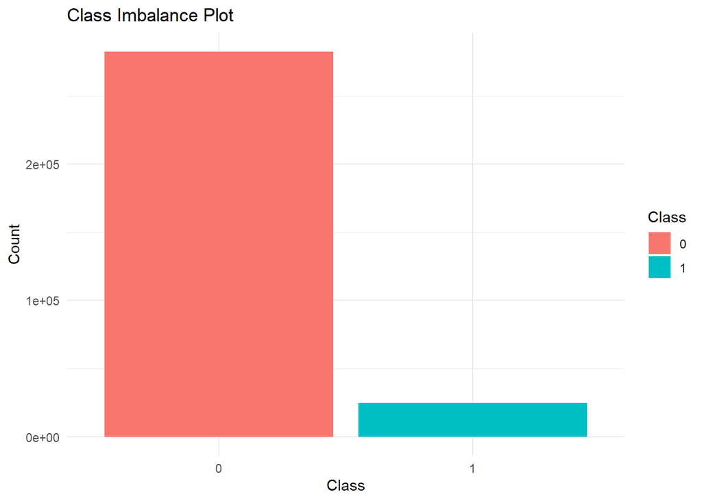

```r
# Summarize the class distribution
class_distribution <- table(application_train$target)

# Convert to a data frame for plotting
class_df <- as.data.frame(class_distribution)
colnames(class_df) <- c("Class", "Count")

# Create the bar plot
ggplot(class_df, aes(x = factor(Class), y = Count, fill = factor(Class))) +
  geom_bar(stat = "identity") +
  labs(
    title = "Class Imbalance Plot",
    x = "Class",
    y = "Count",
    fill = "Class"
  ) +
  theme_minimal()
```

We can notice a class imbalance: the number of clients who do not default (92%) is greater than the number of clients who default(8%).

```r
#Calculate the accuracy of a majority class predictor.
majority_class_accuracy <- max(table(application_train$target)) / nrow(application_train)
majority_class_accuracy
```

```
## [1] 0.9192712
```

The accuracy of a naive majority class predictor is calculated as 91.93%, which is expected given the class imbalance.

To address this, will explore balancing techniques such as SMOTE or undersampling in the modeling phase.

# Step 3: Handling Missing Data and Imputation Strategies

## Handle missing values for numeric and categorical variables

```r
# Summarize missing data only for columns with missing values and round to 2 decimals
missing_data <- application_train %>%
  clean_names() %>%  # Ensures column names are cleaned (if not already)
  summarise(across(everything(), ~sum(is.na(.)) / n())) %>%
  pivot_longer(cols = everything(), names_to = "column", values_to = "missing_fraction") %>%
  filter(missing_fraction > 0) %>%  # Keep only columns with missing values
  mutate(missing_fraction = round(missing_fraction, 4))  # Round to 2 decimal places

# View the result
print(missing_data, n = Inf)  # Show all rows in the console
```

```
## # A tibble: 67 × 2
##    column                       missing_fraction
##    <chr>                                   <dbl>
##  1 amt_annuity                            0
##  2 amt_goods_price                        0.0009
##  3 name_type_suite                        0.0042
##  4 own_car_age                            0.660
##  5 occupation_type                        0.314
##  6 cnt_fam_members                        0
##  7 ext_source_1                           0.564
##  8 ext_source_2                           0.0021
##  9 ext_source_3                           0.198
## 10 apartments_avg                         0.507
## 11 basementarea_avg                       0.585
## 12 years_beginexpluatation_avg            0.488
```

[output cut: 55 more lines]

```r
# Identify the most problematic columns
missing_data <- missing_data %>% arrange(desc(missing_fraction))
print(missing_data, n = Inf)
```

```
## # A tibble: 67 × 2
##    column                       missing_fraction
##    <chr>                                   <dbl>
##  1 commonarea_avg                         0.699
##  2 commonarea_mode                        0.699
##  3 commonarea_medi                        0.699
##  4 nonlivingapartments_avg                0.694
##  5 nonlivingapartments_mode               0.694
##  6 nonlivingapartments_medi               0.694
##  7 fondkapremont_mode                     0.684
##  8 livingapartments_avg                   0.684
##  9 livingapartments_mode                  0.684
## 10 livingapartments_medi                  0.684
## 11 floorsmin_avg                          0.678
## 12 floorsmin_mode                         0.678
```

[output cut: 55 more lines]

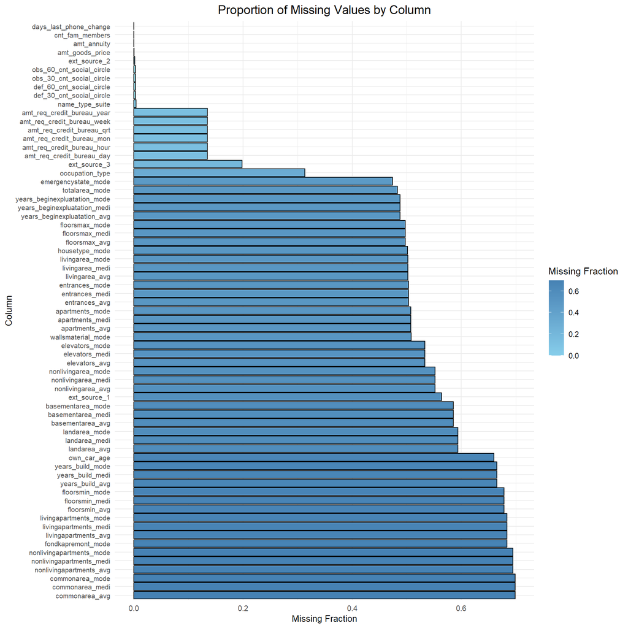

```r
#Visualize missing values
ggplot(missing_data, aes(x = reorder(column, -missing_fraction), y = missing_fraction)) +
  geom_bar(stat = "identity", aes(fill = missing_fraction), color = "black") +
  coord_flip() +  # Flip coordinates for readability
  scale_fill_gradient(low = "skyblue", high = "steelblue", name = "Missing Fraction") +
  labs(
    title = "Proportion of Missing Values by Column",
    x = "Column",
    y = "Missing Fraction"
  ) +
  theme_minimal() +
  theme(
    axis.text.y = element_text(size = 8),  # Smaller text for y-axis labels
    axis.title.y = element_text(size = 10),
    axis.title.x = element_text(size = 10),
    plot.title = element_text(hjust = 0.5, size = 14)  # Center the title
  )
```

```r
# Dropp columns with missing values that are weakly correlated with the target variable

# Step 1: Identify columns with missing values
missing_cols <- names(application_train)[colSums(is.na(application_train)) > 0]

# Step 2: Calculate correlations for numeric columns
correlations <- application_train %>%
  select(all_of(missing_cols), target) %>%  # Select columns with missing values and target
  select(where(is.numeric)) %>%  # Keep only numeric columns for correlation
  cor(use = "pairwise.complete.obs")  # Correlation matrix (pairwise for handling missing values)

# Extract correlations with the target variable
target_correlations <- correlations["target", ] %>% na.omit()

# Step 3: Filter columns with low correlation (e.g., abs(correlation) < 0.05)
low_corr_cols <- names(target_correlations[abs(target_correlations) < 0.05])

# Step 4: Drop columns with low correlation and missing values
columns_to_drop <- intersect(missing_cols, low_corr_cols)
application_train <- application_train %>% select(-all_of(columns_to_drop))

# View the columns dropped
cat("Dropped columns:", paste(columns_to_drop, collapse = ", "), "\n")
```

```
## Dropped columns: amt_annuity, amt_goods_price, own_car_age, cnt_fam_members, apartments_avg, basementarea_avg, years_beginexpluatation_avg, years_build_avg, commonarea_avg, elevators_avg, entrances_avg, floorsmax_avg, floorsmin_avg, landarea_avg, livingapartments_avg, livingarea_avg, nonlivingapa…
```

```r
# Identify the remaining columns with missing values
remaining_missing_cols <- setdiff(missing_cols, columns_to_drop)
# Check their missing value counts
remaining_missing_values <- colSums(is.na(application_train[remaining_missing_cols]))
print(remaining_missing_values)
```

```
##        name_type_suite        occupation_type           ext_source_1
##                   1292                  96391                 173378
##           ext_source_2           ext_source_3     fondkapremont_mode
##                    660                  60965                 210295
##         housetype_mode     wallsmaterial_mode    emergencystate_mode
##                 154297                 156341                 145755
## days_last_phone_change
##                      1
```

```r
# Calculate numeric columns correlation with the target variable

# Filter remaining numeric columns with missing values
numeric_remaining_cols <- remaining_missing_cols[remaining_missing_cols %in% names(application_train %>% select(where(is.numeric)))]

# Extract correlations for remaining numeric columns with the target variable
numeric_remaining_correlations <- target_correlations[numeric_remaining_cols]

# Print the correlations
cat("Correlations with the target variable (numeric columns only):\n")
```

```
## Correlations with the target variable (numeric columns only):
```

```r
print(numeric_remaining_correlations)
```

```
##           ext_source_1           ext_source_2           ext_source_3
##            -0.15531713            -0.16047167            -0.17891870
## days_last_phone_change
##             0.05521848
```

- ext_source_1, ext_source_2, and ext_source_3 have notable correlations with the target variable (negative correlations of around -0.15 to -0.18).These numeric columns should be retained, and their missing values can be imputed (e.g., using the median or a predictive model).
- days_last_phone_change has a weak positive correlation (0.055), which could still be retained depending on its importance to the model.
1. **ext_source_1, ext_source_2, ext_source_3:** Since these features are continuous and highly correlated with the target variable, their missing values can be imputed using the median, which is robust to outliers.

```r
# Recommendation

application_train$ext_source_1 <- ifelse(is.na(application_train$ext_source_1),
                                         median(application_train$ext_source_1, na.rm = TRUE),
                                         application_train$ext_source_1)

application_train$ext_source_2 <- ifelse(is.na(application_train$ext_source_2),
                                         median(application_train$ext_source_2, na.rm = TRUE),
                                         application_train$ext_source_2)

application_train$ext_source_3 <- ifelse(is.na(application_train$ext_source_3),
                                         median(application_train$ext_source_3, na.rm = TRUE),
                                         application_train$ext_source_3)
```

2. **days_last_phone_change:** Since this variable might represent a time duration, considered imputing missing values with the median to preserve the central tendency of the data.

```r
application_train$days_last_phone_change <- ifelse(is.na(application_train$days_last_phone_change),
                                                   median(application_train$days_last_phone_change, na.rm = TRUE),
                                                   application_train$days_last_phone_change)
```

```r
# # Calculate categorical columns association with the target variable

# Filter remaining categorical columns with missing values
categorical_remaining_cols <- remaining_missing_cols[!(remaining_missing_cols %in% names(application_train %>% select(where(is.numeric))))]

# Print the categorical columns
cat("Remaining categorical columns with missing values:\n")
```

```
## Remaining categorical columns with missing values:
```

```r
print(categorical_remaining_cols)
```

```
## [1] "name_type_suite"     "occupation_type"     "fondkapremont_mode"
## [4] "housetype_mode"      "wallsmaterial_mode"  "emergencystate_mode"
```

```r
# Perform Chi-Square test for each categorical column
chi_square_results <- lapply(categorical_remaining_cols, function(col) {
  chisq.test(table(application_train[[col]], application_train$target), simulate.p.value = TRUE)
})

# Extract p-values from the test
chi_square_pvalues <- sapply(chi_square_results, function(x) x$p.value)

# Print p-values
names(chi_square_pvalues) <- categorical_remaining_cols
cat("Chi-Square Test p-values for remaining categorical columns:\n")
```

```
## Chi-Square Test p-values for remaining categorical columns:
```

```r
print(chi_square_pvalues)
```

```
##     name_type_suite     occupation_type  fondkapremont_mode      housetype_mode
##        0.0004997501        0.0004997501        0.0009995002        0.0004997501
##  wallsmaterial_mode emergencystate_mode
##        0.0004997501        0.0004997501
```

A p-value < 0.05 indicates a statistically significant association between the variable and the target. These categorical variables are likely important predictors for the model and should be retained for further analysis.

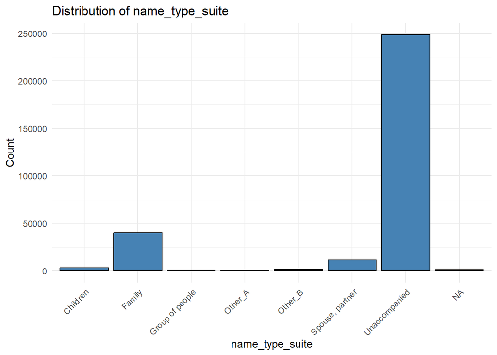

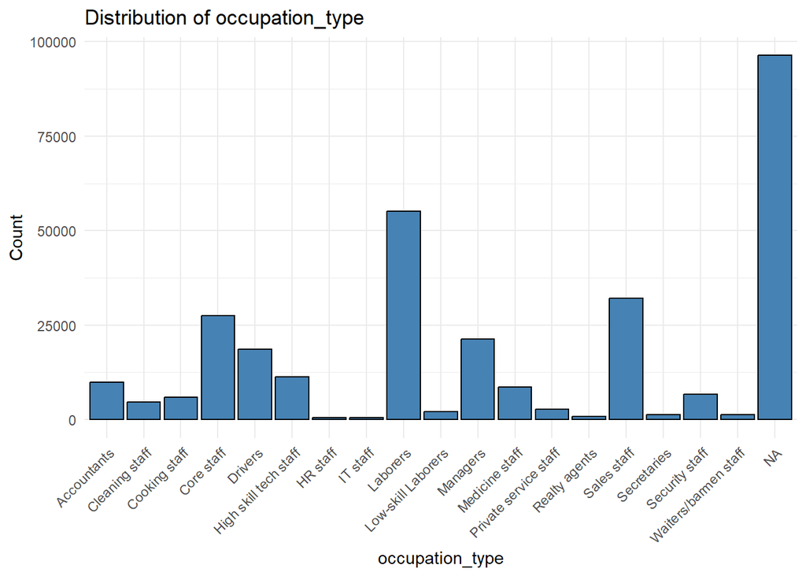

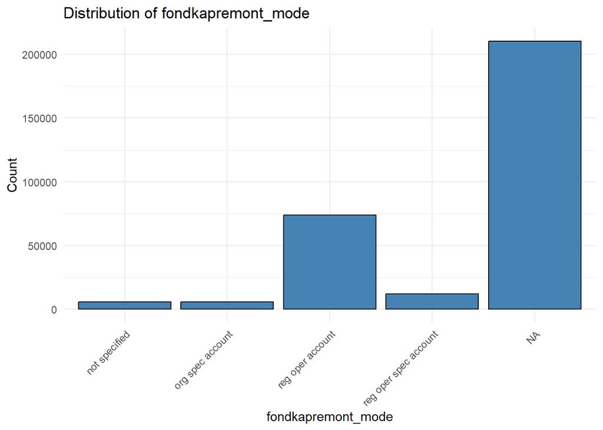

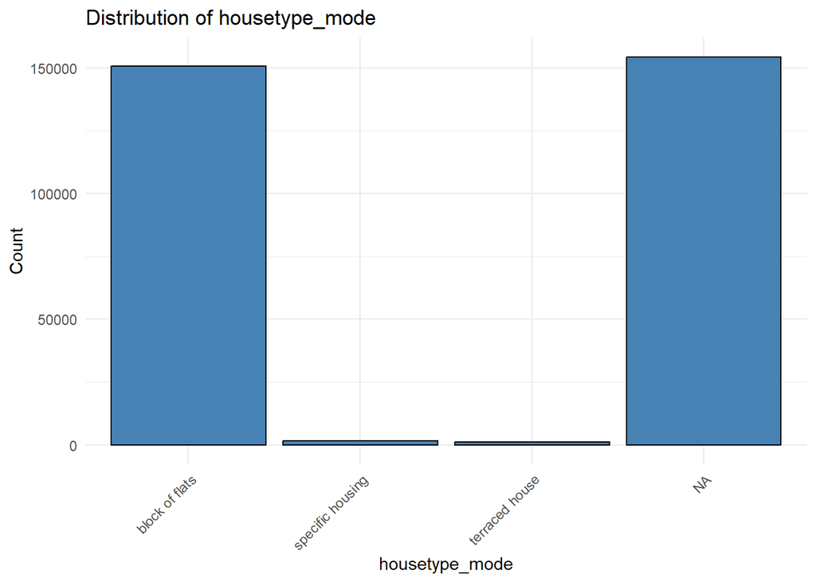

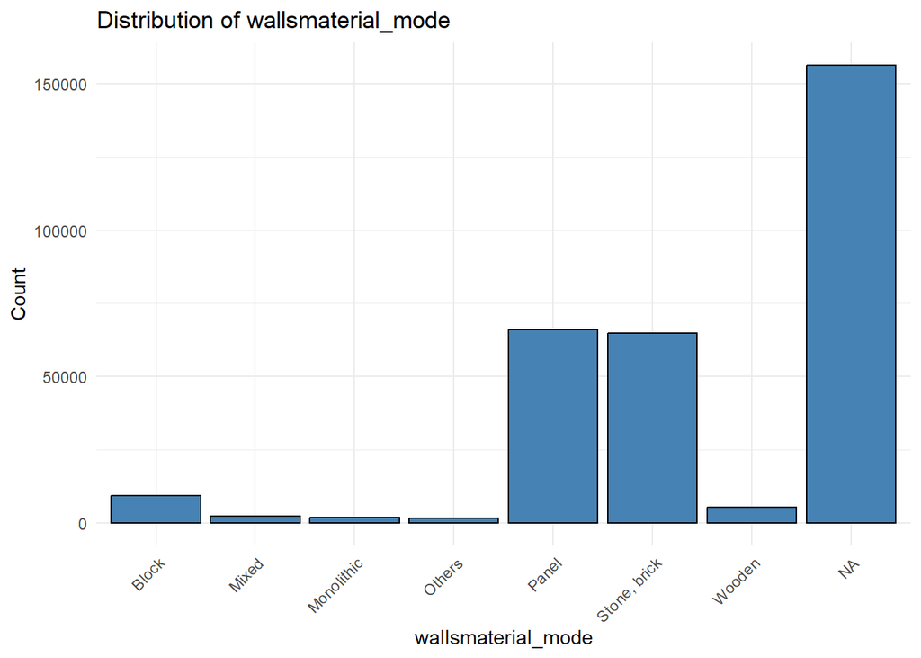

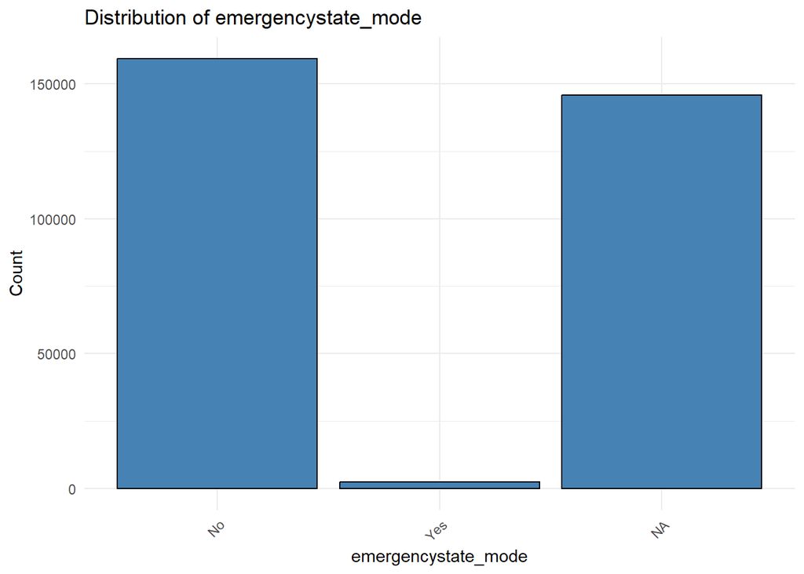

```r
categorical_cols <- c("name_type_suite", "occupation_type", "fondkapremont_mode",
                      "housetype_mode", "wallsmaterial_mode", "emergencystate_mode")

for (col in categorical_cols) {
  p <- ggplot(application_train, aes_string(x = col)) +
    geom_bar(fill = "steelblue", color = "black") +
    labs(title = paste("Distribution of", col), x = col, y = "Count") +
    theme_minimal() +
    theme(axis.text.x = element_text(angle = 45, hjust = 1))

  print(p)  # Print the plot within the loop
}
```

1. **Name_type_suite:** There are a moderate number of missing values (NA), which might indicate the absence of a specific “suite” type during application. Here I will impute with “Unaccompanied”, since it’s the most common category, it might be a reasonable assumption.

```r
# Recommendation
application_train$name_type_suite <- replace_na(application_train$name_type_suite, "Unaccompanied")
```

```r
# Replace NA values in the variable with "Unaccompanied"
application_test$name_type_suite[is.na(application_test$name_type_suite)] <- "Unaccompanied" # Im doing this now to don't have issues when one hot encode the dataset.
```

2. **occupation_type:** There is a significant proportion of NA values. These could indicate:
- Individuals without recorded employment (e.g., students, unemployed).
- Missing data during collection.

Here, as a solution I will impute Missing Values with “Unemployed/Missing”, creating a new category to retain the missingness information.

```r
# Recommendation
application_train$occupation_type <- replace_na(application_train$occupation_type, "Unemployed/Missing")
```

3. **fondkapremont_mode:** This variable likely reflects how maintenance funds are managed, and NA might indicate that the applicant does not contribute to such a fund. I will impute missing values with “Not Applicable”, since NA might indicate no participation in maintenance funds, this would be logical.

```r
# Recommendation
application_train$fondkapremont_mode <- replace_na(application_train$fondkapremont_mode, "Not Applicable")
```

```r
# Recommendation
application_train$housetype_mode <- replace_na(application_train$housetype_mode, "Not Specified")
```

5. **wallsmaterial_mode:** “Panel” and “Stone, brick” dominate the distribution, with a significant number of NA values. NA might mean no information about wall material was collected. I will impute Missing Values with “Not Specified”, so this retains the missingness information.

```r
# Recommendation
application_train$wallsmaterial_mode <- replace_na(application_train$wallsmaterial_mode, "Not Specified")
```

6. **emergencystate_mode:** “No” dominates the distribution, and very few entries are “Yes.” NA might indicate that the emergency state status was not recorded or is not applicable.I will impute Missing Values with “No”, since “No” is overwhelmingly common, it’s a practical choice.

```r
# Recommendation
application_train$emergencystate_mode <- replace_na(application_train$emergencystate_mode, "No")
```

## Summary of actions taken

**1. Numeric columns:** Imputed ext_source_1, ext_source_2, ext_source_3, and days_last_phone_change with their respective median values due to their correlations with the target variable.

**2. Categorical columns:** Performed Chi-Square tests and found all categorical variables to have statistically significant associations with the target variable (p-value < 0.05).

- **Imputed:**
- name_type_suite with “Unaccompanied” (most common value).
- occupation_type with “Unemployed/Missing” (to capture missingness information).
- fondkapremont_mode with “Not Applicable” (logical assumption based on missingness).
- housetype_mode with “Not Specified” (to retain missingness information).
- wallsmaterial_mode with “Not Specified” (similar reasoning as above).
- emergencystate_mode with “No” (dominant value).

# Step 4: Feature importance and selection

Given the size of the train dataset (307,511 observations and 65 variables) and the current workflow, I decided to perform feature importance selection first and then balance the dataset for the following reasons:

- The dataset is large, and balancing it before feature selection could significantly increase its size (e.g., oversampling with SMOTE).
- Reducing the number of features first will make subsequent steps (like balancing and model training) faster and more efficient.
- If synthetic data influences feature importance, it could lead to overemphasis on certain features that might not generalize well.
- Balancing the dataset (especially with SMOTE or oversampling) can introduce synthetic data. Performing feature selection afterward ensures only include features that genuinely contribute to the model’s predictions.

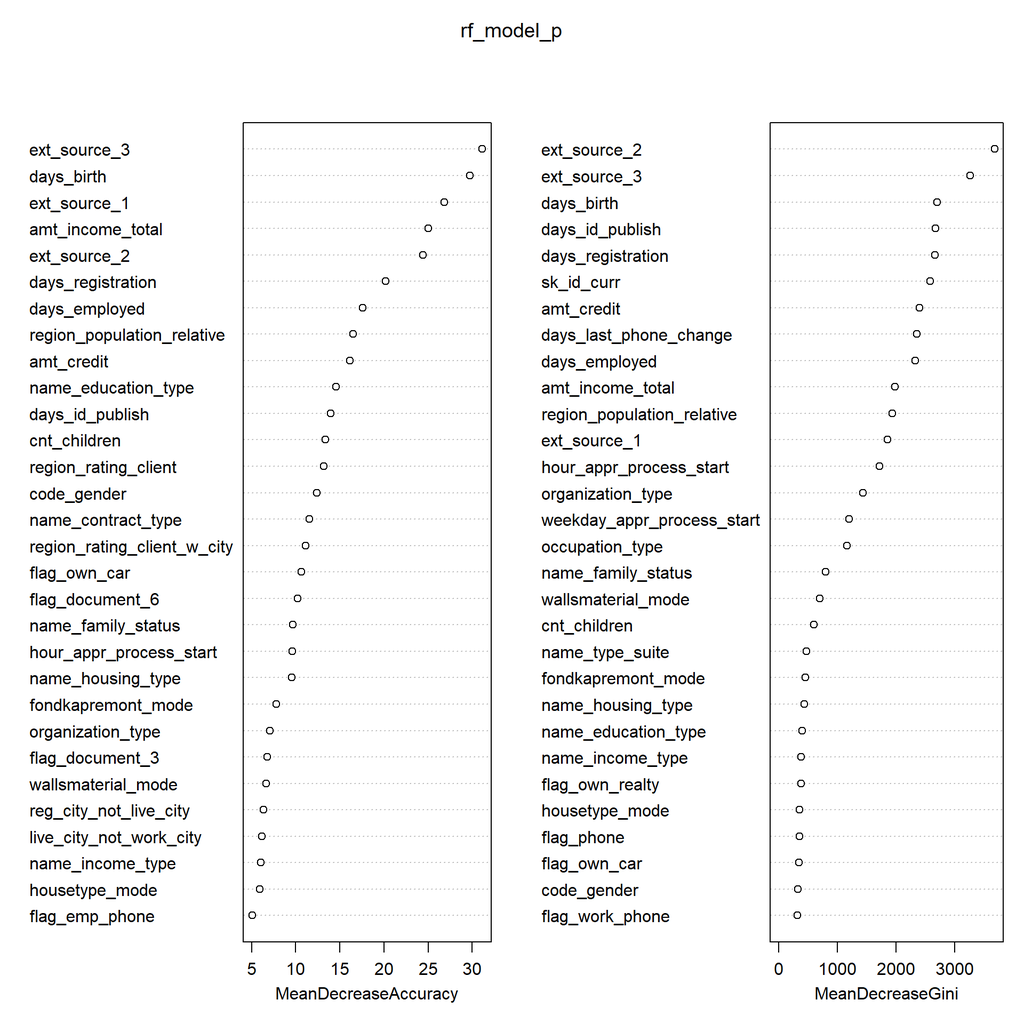

```r
# Ensure the target Variable is a Factor
application_train$target <- as.factor(application_train$target)

# Ensure levels are properly defined as 0 and 1
application_train$target <- factor(application_train$target, levels = c("0", "1"))

# Random Forest Feature Importance
set.seed(123)
rf_model_p <- randomForest(target ~ ., data = application_train, importance = TRUE, ntree = 50)
importance <- importance(rf_model_p)
varImpPlot(rf_model_p)
```

```r
# Select top 25 features
important_vars <- names(sort(importance[, "MeanDecreaseGini"], decreasing = TRUE)[1:25])
reduced_data <- application_train[, c(important_vars, "target")]
```

```r
print(important_vars)
```

```
##  [1] "ext_source_2"               "ext_source_3"
##  [3] "days_birth"                 "days_id_publish"
##  [5] "days_registration"          "sk_id_curr"
##  [7] "amt_credit"                 "days_last_phone_change"
##  [9] "days_employed"              "amt_income_total"
## [11] "region_population_relative" "ext_source_1"
## [13] "hour_appr_process_start"    "organization_type"
## [15] "weekday_appr_process_start" "occupation_type"
## [17] "name_family_status"         "wallsmaterial_mode"
## [19] "cnt_children"               "name_type_suite"
## [21] "fondkapremont_mode"         "name_housing_type"
## [23] "name_education_type"        "name_income_type"
## [25] "flag_own_realty"
```

- sk_id_curr can be excluded as it serves no predictive purpose.

Feature importance was assessed using a Random Forest model. Variables like “ext_source_2” and “days_birth” showed high importance, indicating their strong predictive power for default predictions.

```r
# Drop the 'sk_id_curr' column from the dataset
reduced_data <- reduced_data[, !names(reduced_data) %in% "sk_id_curr"]

# Check if the column has been dropped
print("sk_id_curr" %in% names(reduced_data))  # Should return FALSE
```

```
## [1] FALSE
```

```r
# View the column names
names(reduced_data)
```

```
##  [1] "ext_source_2"               "ext_source_3"
##  [3] "days_birth"                 "days_id_publish"
##  [5] "days_registration"          "amt_credit"
##  [7] "days_last_phone_change"     "days_employed"
##  [9] "amt_income_total"           "region_population_relative"
## [11] "ext_source_1"               "hour_appr_process_start"
## [13] "organization_type"          "weekday_appr_process_start"
## [15] "occupation_type"            "name_family_status"
## [17] "wallsmaterial_mode"         "cnt_children"
## [19] "name_type_suite"            "fondkapremont_mode"
## [21] "name_housing_type"          "name_education_type"
## [23] "name_income_type"           "flag_own_realty"
## [25] "target"
```

# Step 5: Handle outliers

Focus in numeric columns:

```r
# Identify numeric columns
numeric_cols <- names(reduced_data)[sapply(reduced_data, is.numeric)]
```

Identify outliers for each numeric column:

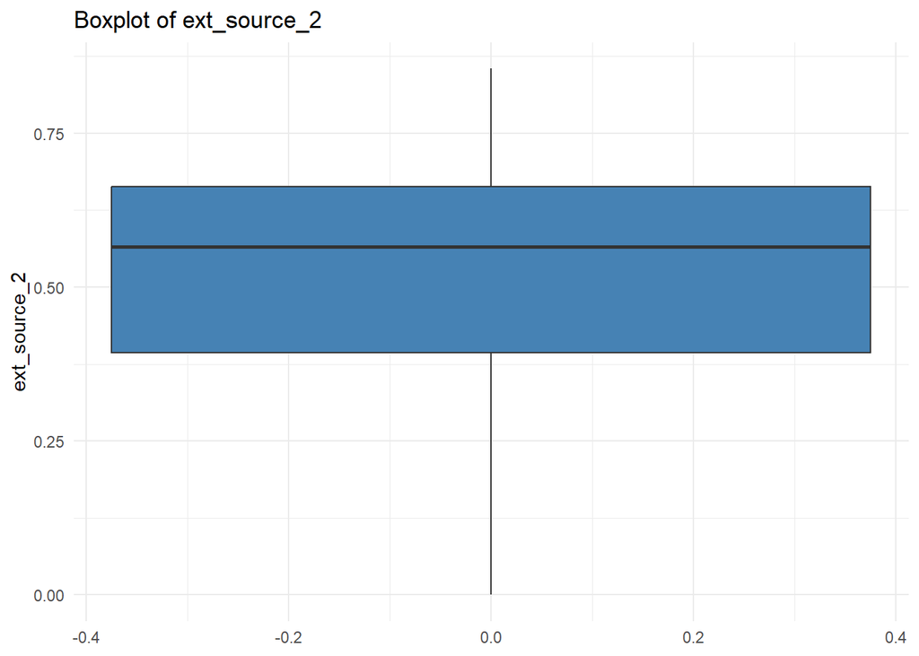

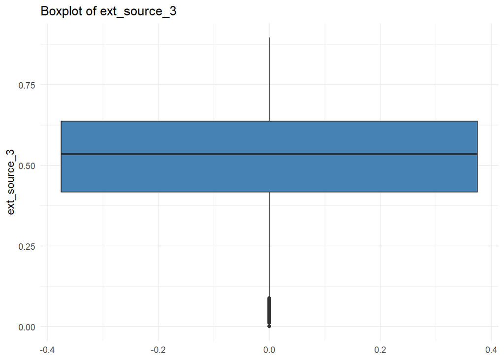

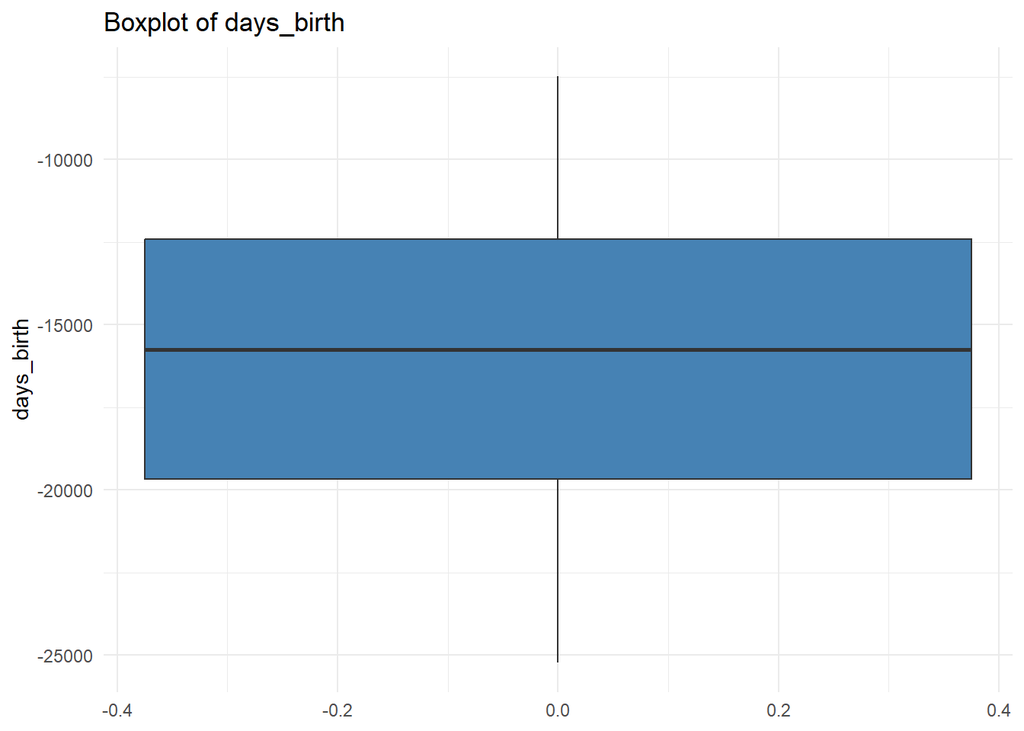

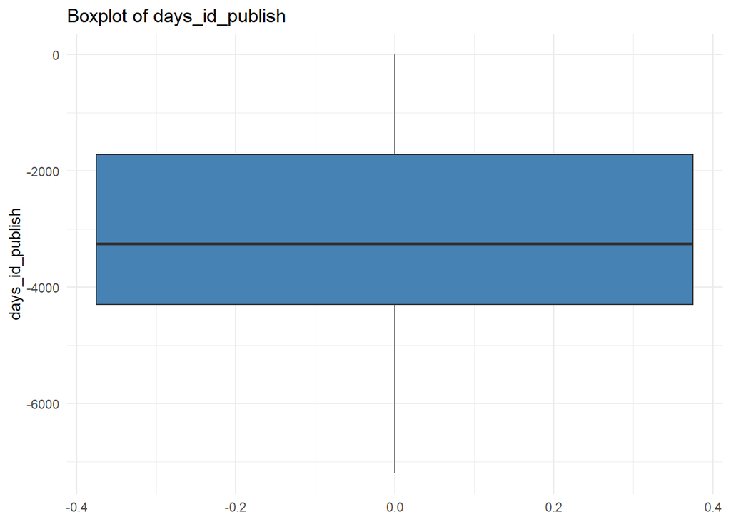

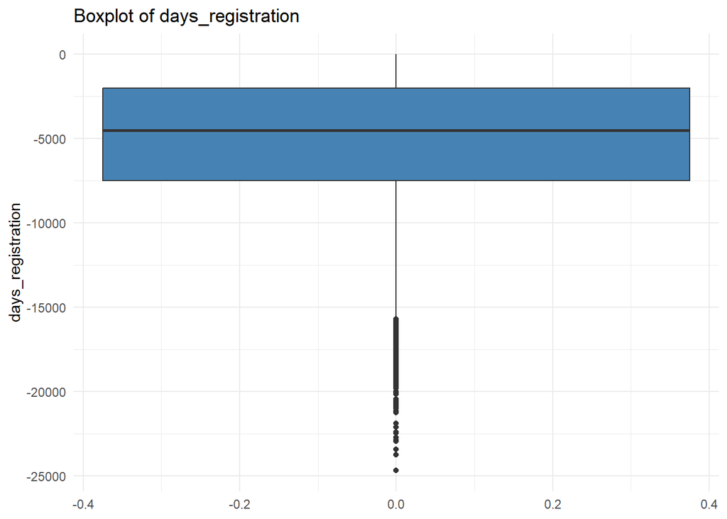

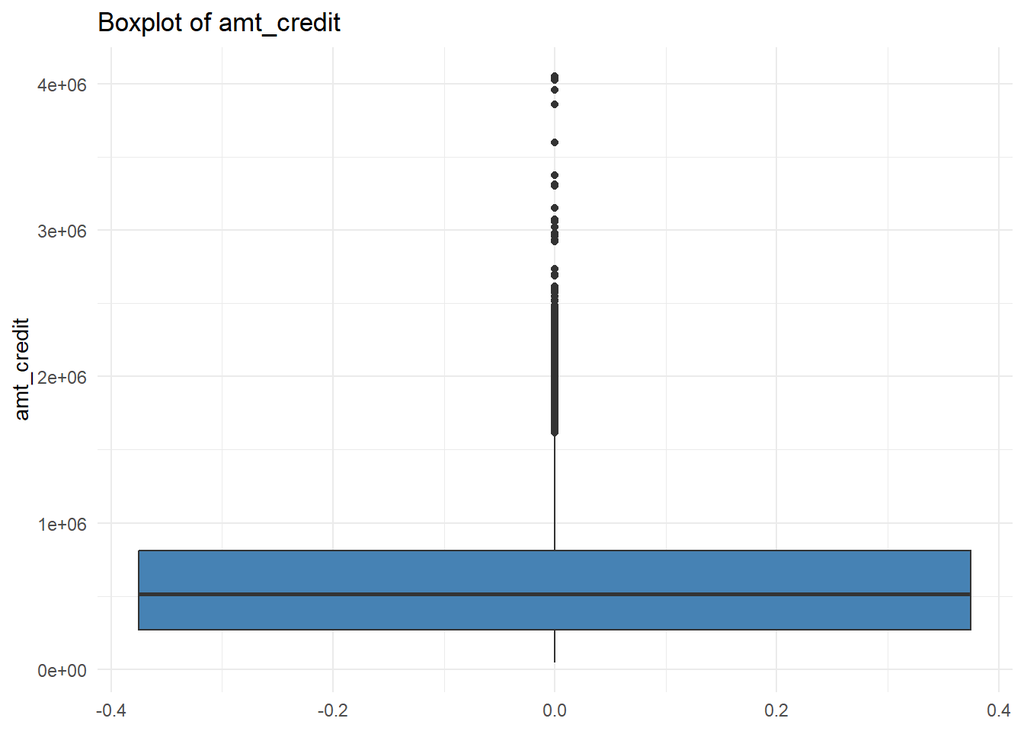

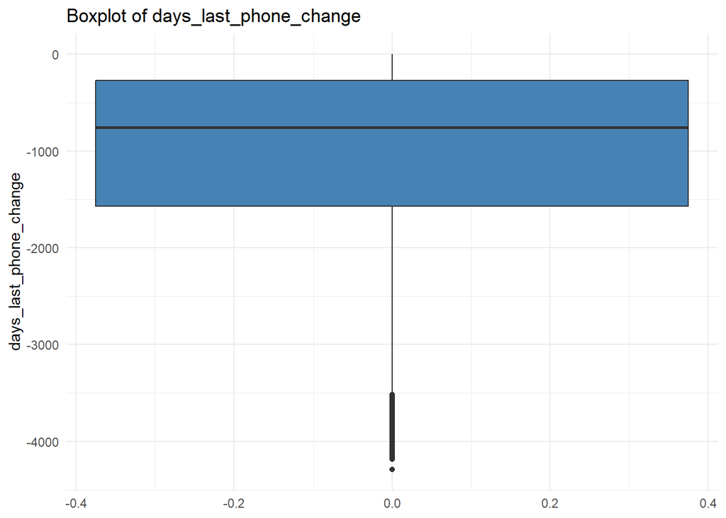

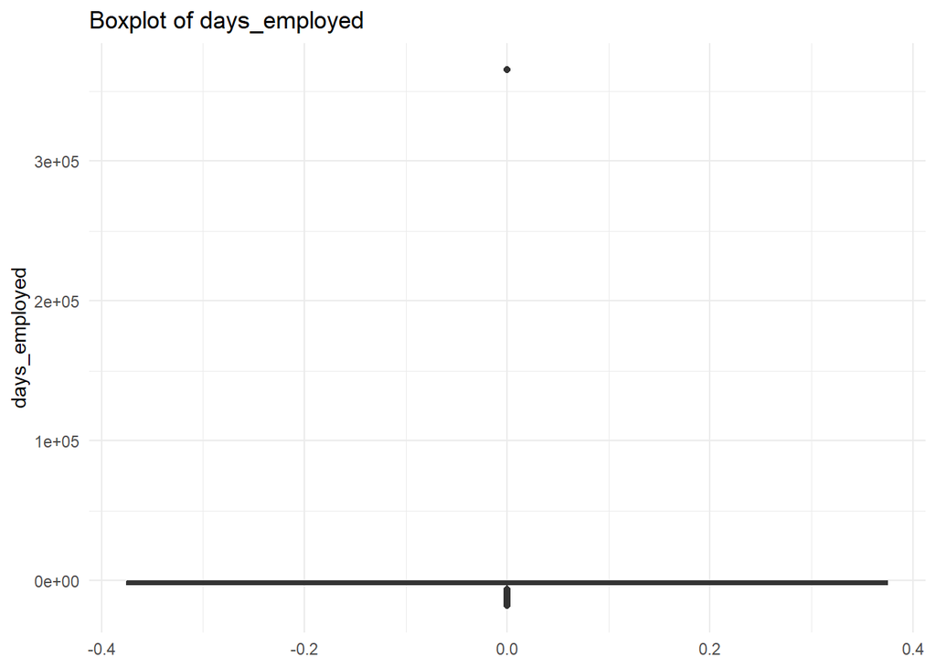

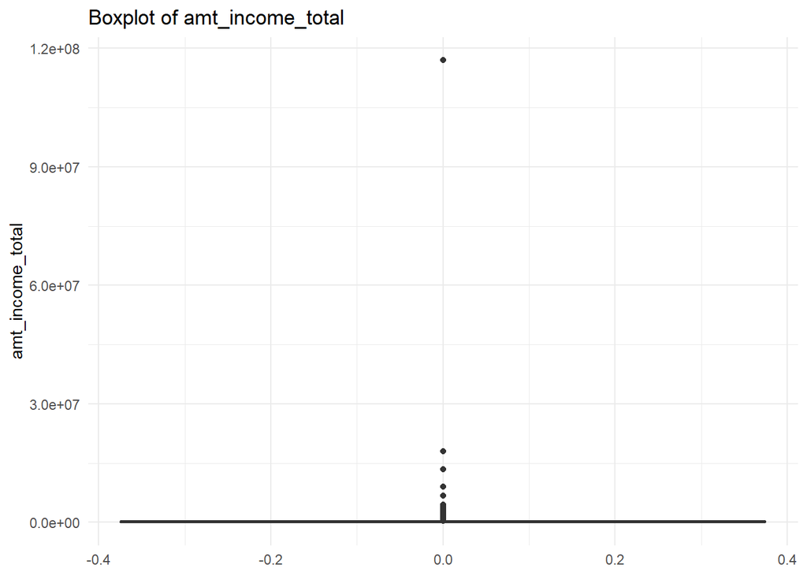

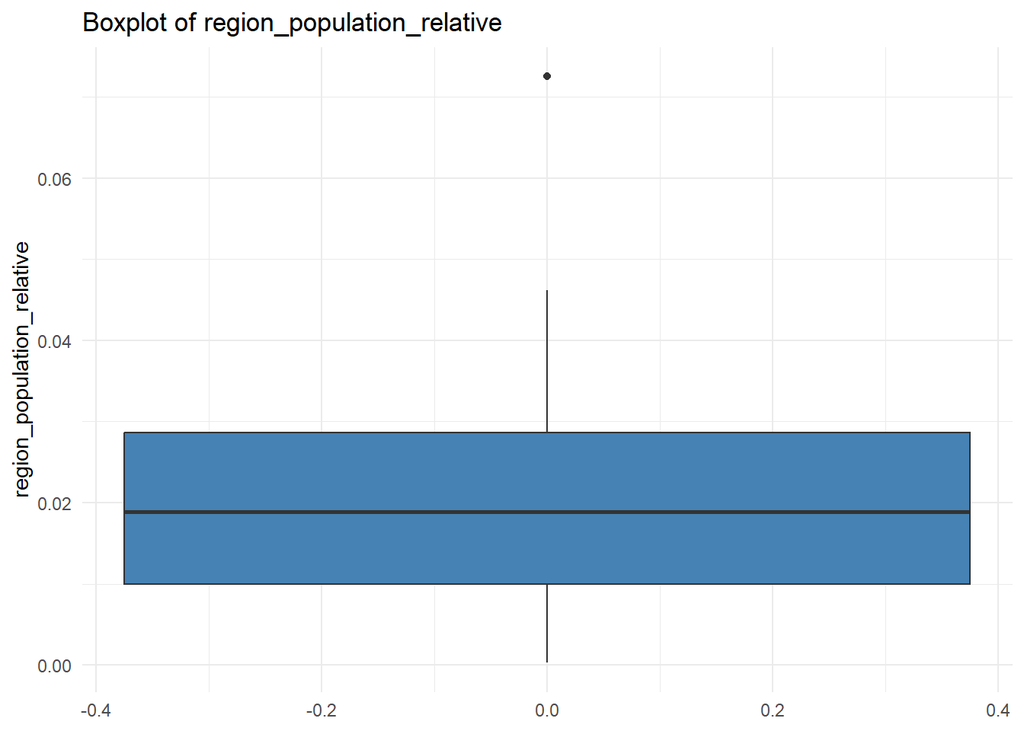

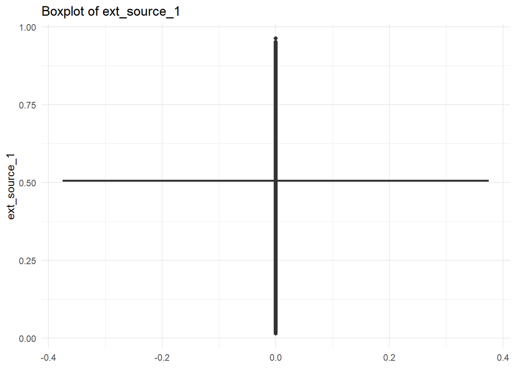

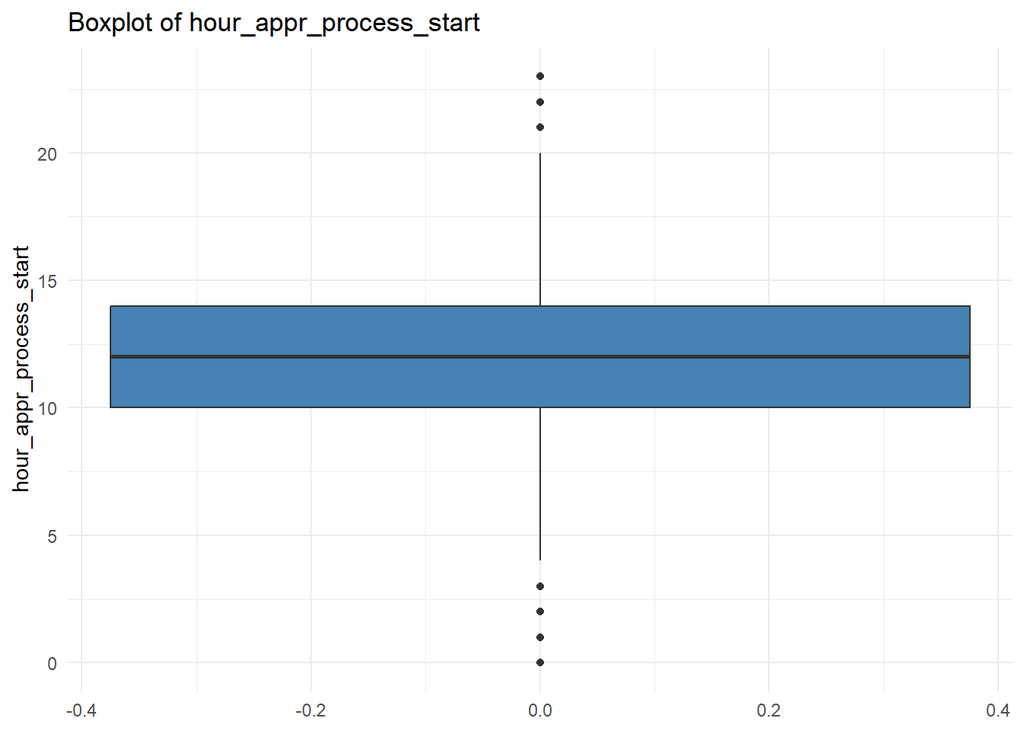

[1 more figures not shown]

```r
# Using boxplots
# Loop through numeric columns to create boxplots
for (col in numeric_cols) {
  print(
    ggplot(reduced_data, aes_string(y = col)) +
      geom_boxplot(fill = "steelblue") +
      labs(title = paste("Boxplot of", col), y = col) +
      theme_minimal()
  )
}
```

```r
# Using IQR Method
# Function to detect outliers based on IQR
detect_outliers <- function(data, col) {
  q1 <- quantile(data[[col]], 0.25, na.rm = TRUE)
  q3 <- quantile(data[[col]], 0.75, na.rm = TRUE)
  iqr <- q3 - q1
  lower_bound <- q1 - 1.5 * iqr
  upper_bound <- q3 + 1.5 * iqr
  data[data[[col]] < lower_bound | data[[col]] > upper_bound, ]
}

# Detect outliers for each numeric column
outliers <- lapply(numeric_cols, function(col) detect_outliers(reduced_data, col))

# Count the number of outliers in each column
outlier_counts <- sapply(outliers, nrow)
print(outlier_counts)
```

```
##  [1]      0   4313      0      0    659   6562    435  72217  14035   8412
## [11] 134131   2257   4272
```

The numeric variables with outliers are:

- **ext_source_3 (4313):** Outliers are present near the lower bound (close to 0).

```r
# Recommendation
# Cap outliers at the nearest boundary (0). Winsorize the upper bound as well
reduced_data$ext_source_3 <- pmax(reduced_data$ext_source_3, 0)
reduced_data$ext_source_3 <- Winsorize(reduced_data$ext_source_3)
```

- **days_registration(659):** Extreme outliers on the lower end (very negative values).Number of days since registration, with negatives indicating past dates.

```r
# Recommendation
# Cap extreme values using the 1.5 × IQR boundary
reduced_data$days_registration <- Winsorize(reduced_data$days_registration)
```

- **amt_credit(6562):** Upper outliers, possibly very large credit amounts.

```r
# Recommendation
# Apply log1p() to reduce skewness and compress large values
reduced_data$amt_credit <- Winsorize(reduced_data$amt_credit)
```

- **days_last_phone_change (435):** Lower bound outliers, with very negative values. Days since last phone change (negative means past).

```r
# Recommendation
# Replace outliers with the median, assuming very old phone changes are less meaningful.

median_value <- median(reduced_data$days_last_phone_change, na.rm = TRUE)
reduced_data$days_last_phone_change <- pmax(reduced_data$days_last_phone_change, median_value)
```

- **days_employed(72217):** this variables has 72217 observations with one positive outlier 365243.

```r
# Recommendation
# Replace the extreme value with NA
reduced_data$days_employed[reduced_data$days_employed == 365243] <- NA
# Replace NA values with the median
reduced_data$days_employed <- ifelse(is.na(reduced_data$days_employed),
                                     median(reduced_data$days_employed, na.rm = TRUE),
                                     reduced_data$days_employed)

# After replace with median still having 23148 observations with outliers.
# Calculate IQR, Q1, and Q3
q1 <- quantile(reduced_data$days_employed, 0.25, na.rm = TRUE)
q3 <- quantile(reduced_data$days_employed, 0.75, na.rm = TRUE)
iqr <- q3 - q1

# Define bounds
lower_bound <- q1 - 1.5 * iqr
upper_bound <- q3 + 1.5 * iqr

# Winsorize outliers
reduced_data$days_employed <- ifelse(reduced_data$days_employed < lower_bound, lower_bound,
                                     ifelse(reduced_data$days_employed > upper_bound, upper_bound,
                                            reduced_data$days_employed))
```

- **amt_income_total(14035):** Extreme upper outliers

```r
# Recommendation
# log tranformation: compress the skewed distribution to better handle extremes
reduced_data$amt_income_total <- log1p(reduced_data$amt_income_total)
reduced_data$amt_income_total <- Winsorize(reduced_data$amt_income_total)
```

- **region_population_relative(8412):** A upper outlier (0.06)

```r
# Recommendation
# Cap the outliers using the 1.5 × IQR boundary, as it’s likely valid but extreme
reduced_data$region_population_relative <- Winsorize(reduced_data$region_population_relative)
```

```r
# Recommendation

# Calculate IQR, Q1, and Q3
q1 <- quantile(reduced_data$ext_source_1, 0.25, na.rm = TRUE)
q3 <- quantile(reduced_data$ext_source_1, 0.75, na.rm = TRUE)
iqr <- q3 - q1

# Define bounds
lower_bound <- q1 - 1.5 * iqr
upper_bound <- q3 + 1.5 * iqr

# Winsorize outliers
reduced_data$ext_source_1 <- ifelse(reduced_data$ext_source_1 < lower_bound, lower_bound,
                                    ifelse(reduced_data$ext_source_1 > upper_bound, upper_bound,
                                           reduced_data$ext_source_1))
```

- **hour_appr_process_start(2257):** Small number of outliers near the lower and upper bounds.

```r
# Recommendation
#  Capping outliers at the 1.5 × IQR boundary
reduced_data$hour_appr_process_start <- Winsorize(reduced_data$hour_appr_process_start)
```

- **cnt_children(4272):**Few extreme outliers with large numbers of children. While it’s possible to have more children, such cases are rare and could introduce noise into the model.

```r
# Recommendation
#  Cap values above a realistic threshold (e.g. 10 children).
#reduced_data$cnt_children <- pmin(reduced_data$cnt_children, 10) this didnt work.
# Remove rows with extreme values #reduced_data <- reduced_data[reduced_data$cnt_children <= 10, ] this didnt work either.

q1 <- quantile(reduced_data$cnt_children, 0.25, na.rm = TRUE)
q3 <- quantile(reduced_data$cnt_children, 0.75, na.rm = TRUE)
iqr <- q3 - q1
upper_bound <- q3 + 1.5 * iqr
reduced_data$cnt_children[reduced_data$cnt_children > upper_bound] <- upper_bound
```

```r
# Identify numeric columns
numeric_cols <- names(reduced_data)[sapply(reduced_data, is.numeric)]

# Recheck for remaining outliers
outlier_counts <- sapply(numeric_cols, function(col) {
  Q1 <- quantile(reduced_data[[col]], 0.25, na.rm = TRUE)
  Q3 <- quantile(reduced_data[[col]], 0.75, na.rm = TRUE)
  IQR <- Q3 - Q1
  lower_bound <- Q1 - 1.5 * IQR
  upper_bound <- Q3 + 1.5 * IQR
  sum(reduced_data[[col]] < lower_bound | reduced_data[[col]] > upper_bound, na.rm = TRUE)
})
print(outlier_counts)
```

```
##               ext_source_2               ext_source_3
##                          0                          0
##                 days_birth            days_id_publish
##                          0                          0
##          days_registration                 amt_credit
##                          0                          0
##     days_last_phone_change              days_employed
##                          0                          0
##           amt_income_total region_population_relative
##                          0                          0
##               ext_source_1    hour_appr_process_start
##                          0                          0
##               cnt_children
##                          0
```

# Step 6: Data Preprocessing and Feature Alignment

## Conversion of categorical columns to factors

```r
# Convert categorical columns in reduced_data to factors
reduced_data <- reduced_data %>%
  mutate(across(where(is.character), as.factor))
```

```r
# Lets do the same for the application_test dataset
application_test <- application_test %>%
  mutate(across(where(is.character), as.factor))
```

```r
# Separate the target variable fromt the reduced_data dataset
target <- reduced_data$target
# reduced_data without the target variable
predictors <- reduced_data[, -which(names(reduced_data) == "target")]
```

```r
# Check the predictors from the reduced_data dataset
str(predictors)
```

```
## tibble [307,511 × 24] (S3: tbl_df/tbl/data.frame)
##  $ ext_source_2              : num [1:307511] 0.263 0.622 0.556 0.65 0.323 ...
##  $ ext_source_3              : num [1:307511] 0.175 0.535 0.73 0.535 0.535 ...
##  $ days_birth                : num [1:307511] -9461 -16765 -19046 -19005 -19932 ...
##  $ days_id_publish           : num [1:307511] -2120 -291 -2531 -2437 -3458 ...
##  $ days_registration         : num [1:307511] -3648 -1186 -4260 -9833 -4311 ...
##  $ amt_credit                : num [1:307511] 406598 1293503 135000 312683 513000 ...
##  $ days_last_phone_change    : num [1:307511] -757 -757 -757 -617 -757 -757 -757 -757 0 -757 ...
##  $ days_employed             : num [1:307511] -637 -1188 -225 -3039 -3038 ...
##  $ amt_income_total          : num [1:307511] 12.2 12.5 11.1 11.8 11.7 ...
##  $ region_population_relative: num [1:307511] 0.0188 0.00496 0.01003 0.00802 0.02866 ...
##  $ ext_source_1              : num [1:307511] 0.506 0.506 0.506 0.506 0.506 ...
##  $ hour_appr_process_start   : num [1:307511] 10 11 9 17 11 16 16 16 14 8 ...
##  $ organization_type         : Factor w/ 58 levels "Advertising",..: 6 40 12 6 38 34 6 34 58 10 ...
##  $ weekday_appr_process_start: Factor w/ 7 levels "FRIDAY","MONDAY",..: 7 2 2 7 5 7 4 2 7 5 ...
##  $ occupation_type           : Factor w/ 19 levels "Accountants",..: 9 4 9 9 4 9 1 11 18 9 ...
##  $ name_family_status        : Factor w/ 6 levels "Civil marriage",..: 4 2 4 1 4 2 2 2 2 4 ...
##  $ wallsmaterial_mode        : Factor w/ 8 levels "Block","Mixed",..: 7 1 4 4 4 4 4 4 4 4 ...
##  $ cnt_children              : num [1:307511] 0 0 0 0 0 0 1 0 0 0 ...
##  $ name_type_suite           : Factor w/ 7 levels "Children","Family",..: 7 2 7 7 7 6 7 7 1 7 ...
##  $ fondkapremont_mode        : Factor w/ 5 levels "Not Applicable",..: 4 4 1 1 1 1 1 1 1 1 ...
##  $ name_housing_type         : Factor w/ 6 levels "Co-op apartment",..: 2 2 2 2 2 2 2 2 2 2 ...
##  $ name_education_type       : Factor w/ 5 levels "Academic degree",..: 5 2 5 5 5 5 2 2 5 5 ...
##  $ name_income_type          : Factor w/ 8 levels "Businessman",..: 8 5 8 8 8 5 2 5 4 8 ...
##  $ flag_own_realty           : Factor w/ 2 levels "N","Y": 2 1 2 2 2 2 2 2 2 2 ...
```

```r
# Check the predictors from the application_test dataset
str(application_test)
```

```
## tibble [48,744 × 121] (S3: tbl_df/tbl/data.frame)
##  $ sk_id_curr                  : num [1:48744] 1e+05 1e+05 1e+05 1e+05 1e+05 ...
##  $ name_contract_type          : Factor w/ 2 levels "Cash loans","Revolving loans": 1 1 1 1 1 1 1 1 1 1 ...
##  $ code_gender                 : Factor w/ 2 levels "F","M": 1 2 2 1 2 1 2 2 1 1 ...
##  $ flag_own_car                : Factor w/ 2 levels "N","Y": 1 1 2 1 2 2 2 1 1 2 ...
##  $ flag_own_realty             : Factor w/ 2 levels "N","Y": 2 2 2 2 1 2 2 2 2 2 ...
##  $ cnt_children                : num [1:48744] 0 0 0 2 1 0 2 0 0 1 ...
##  $ amt_income_total            : num [1:48744] 135000 99000 202500 315000 180000 ...
##  $ amt_credit                  : num [1:48744] 568800 222768 663264 1575000 625500 ...
##  $ amt_annuity                 : num [1:48744] 20561 17370 69777 49019 32067 ...
##  $ amt_goods_price             : num [1:48744] 450000 180000 630000 1575000 625500 ...
##  $ name_type_suite             : Factor w/ 7 levels "Children","Family",..: 7 7 7 7 7 7 7 7 7 2 ...
##  $ name_income_type            : Factor w/ 7 levels "Businessman",..: 7 7 7 7 7 4 7 7 4 7 ...
##  $ name_education_type         : Factor w/ 5 levels "Academic degree",..: 2 5 2 5 5 5 2 2 2 2 ...
##  $ name_family_status          : Factor w/ 5 levels "Civil marriage",..: 2 2 2 2 2 2 2 4 2 1 ...
```

[output cut: 86 more lines]

```r
# Check for factor columns in the predictors dataset
factor_columns <- names(Filter(is.factor, predictors))
print(factor_columns)
```

```
##  [1] "organization_type"          "weekday_appr_process_start"
##  [3] "occupation_type"            "name_family_status"
##  [5] "wallsmaterial_mode"         "name_type_suite"
##  [7] "fondkapremont_mode"         "name_housing_type"
##  [9] "name_education_type"        "name_income_type"
## [11] "flag_own_realty"
```

The goal in this part of the code is to ensure that the predictors in the application_test dataset match those in the reduced data, as this alignment will be necessary later for testing the best model.

```r
# Ensure the same column names
common_columns_test <- intersect(colnames(application_test), colnames(predictors)) # since application_test doesn't have the target variable

# Filter application_test to keep only common columns
application_test_reduced <- application_test[, common_columns_test, drop = FALSE]

# Reorder columns in application_test to match predictors
application_test_reduced <- application_test_reduced[, colnames(predictors), drop = FALSE]

# Check if the columns match
all_columns_match <- all(colnames(application_test_reduced) == colnames(predictors))
cat("Do all columns match? ", all_columns_match, "\n")
```

```
## Do all columns match?  TRUE
```

```r
# Check for factor columns in the application_test dataset
factor_columns_application_test <- names(Filter(is.factor, application_test))
print(factor_columns_application_test)
```

```
##  [1] "name_contract_type"         "code_gender"
##  [3] "flag_own_car"               "flag_own_realty"
##  [5] "name_type_suite"            "name_income_type"
##  [7] "name_education_type"        "name_family_status"
##  [9] "name_housing_type"          "occupation_type"
## [11] "weekday_appr_process_start" "organization_type"
## [13] "fondkapremont_mode"         "housetype_mode"
## [15] "wallsmaterial_mode"         "emergencystate_mode"
```

## Apply one hot encoding

```r
# One-hot encode categorical variables in the predictors data
encoded_predictors <- dummy_cols(
  predictors,
  select_columns = factor_columns,
  remove_selected_columns = TRUE,
  remove_first_dummy = TRUE  # Avoid multicollinearity
)

# Check the structure of the encoded dataset
str(encoded_predictors)
```

```
## tibble [307,511 × 133] (S3: tbl_df/tbl/data.frame)
##  $ ext_source_2                                     : num [1:307511] 0.263 0.622 0.556 0.65 0.323 ...
##  $ ext_source_3                                     : num [1:307511] 0.175 0.535 0.73 0.535 0.535 ...
##  $ days_birth                                       : num [1:307511] -9461 -16765 -19046 -19005 -19932 ...
##  $ days_id_publish                                  : num [1:307511] -2120 -291 -2531 -2437 -3458 ...
##  $ days_registration                                : num [1:307511] -3648 -1186 -4260 -9833 -4311 ...
##  $ amt_credit                                       : num [1:307511] 406598 1293503 135000 312683 513000 ...
##  $ days_last_phone_change                           : num [1:307511] -757 -757 -757 -617 -757 -757 -757 -757 0 -757 ...
##  $ days_employed                                    : num [1:307511] -637 -1188 -225 -3039 -3038 ...
##  $ amt_income_total                                 : num [1:307511] 12.2 12.5 11.1 11.8 11.7 ...
##  $ region_population_relative                       : num [1:307511] 0.0188 0.00496 0.01003 0.00802 0.02866 ...
##  $ ext_source_1                                     : num [1:307511] 0.506 0.506 0.506 0.506 0.506 ...
##  $ hour_appr_process_start                          : num [1:307511] 10 11 9 17 11 16 16 16 14 8 ...
##  $ cnt_children                                     : num [1:307511] 0 0 0 0 0 0 1 0 0 0 ...
##  $ organization_type_Agriculture                    : int [1:307511] 0 0 0 0 0 0 0 0 0 0 ...
```

[output cut: 86 more lines]

```r
# One-hot encode categorical variables for the application_test
application_test_encoded <- dummy_cols(
  application_test_reduced,
  select_columns = factor_columns_application_test,
  remove_selected_columns = TRUE,
  remove_first_dummy = TRUE  # Avoid multicollinearity
)

# Check the structure of the application test encoded dataset
str(application_test_encoded)
```

```
## tibble [48,744 × 131] (S3: tbl_df/tbl/data.frame)
##  $ ext_source_2                                     : num [1:48744] 0.79 0.292 0.7 0.51 0.426 ...
##  $ ext_source_3                                     : num [1:48744] 0.16 0.433 0.611 0.613 NA ...
##  $ days_birth                                       : num [1:48744] -19241 -18064 -20038 -13976 -13040 ...
##  $ days_id_publish                                  : num [1:48744] -812 -1623 -3503 -4208 -4262 ...
##  $ days_registration                                : num [1:48744] -5170 -9118 -2175 -2000 -4000 ...
##  $ amt_credit                                       : num [1:48744] 568800 222768 663264 1575000 625500 ...
##  $ days_last_phone_change                           : num [1:48744] -1740 0 -856 -1805 -821 ...
##  $ days_employed                                    : num [1:48744] -2329 -4469 -4458 -1866 -2191 ...
##  $ amt_income_total                                 : num [1:48744] 135000 99000 202500 315000 180000 ...
##  $ region_population_relative                       : num [1:48744] 0.0188 0.0358 0.0191 0.0264 0.01 ...
##  $ ext_source_1                                     : num [1:48744] 0.753 0.565 NA 0.526 0.202 ...
##  $ hour_appr_process_start                          : num [1:48744] 18 9 14 11 5 15 9 7 18 14 ...
##  $ cnt_children                                     : num [1:48744] 0 0 0 2 1 0 2 0 0 1 ...
##  $ flag_own_realty_Y                                : int [1:48744] 1 1 1 1 0 1 1 1 1 1 ...
```

[output cut: 86 more lines]

```r
# identify columns that don't match between predictors and application_test
setdiff(colnames(encoded_predictors), colnames(application_test_encoded))
```

```
## [1] "occupation_type_Unemployed/Missing" "name_family_status_Unknown"
## [3] "wallsmaterial_mode_Not Specified"   "fondkapremont_mode_not specified"
## [5] "name_income_type_Maternity leave"
```

```r
# identify columns that don't match between application_test and predictors
setdiff(colnames(application_test_encoded), colnames(encoded_predictors))
```

```
## [1] "occupation_type_NA"    "fondkapremont_mode_NA" "wallsmaterial_mode_NA"
```

```r
# Rename columns in application_test_encoded
application_test_encoded <- application_test_encoded %>%
  rename(
    "occupation_type_Unemployed/Missing" = "occupation_type_NA",
    "wallsmaterial_mode_Not Specified" = "wallsmaterial_mode_NA",
    "fondkapremont_mode_not specified" = "fondkapremont_mode_NA",
  )
```

```r
# identify again columns that don't match between predictors and application_test
setdiff(colnames(encoded_predictors), colnames(application_test_encoded))
```

```
## [1] "name_family_status_Unknown"       "name_income_type_Maternity leave"
```

These two columns are not present in application_test_encoded because there are no levels with these names in the application_test_encoded dataset.

```r
# Add the target variable back to the dataset (encoded_predictors)
final_train <- cbind(encoded_predictors, target)

# Verify the structure of the final dataset
str(final_train)
```

```
## 'data.frame':    307511 obs. of  134 variables:
##  $ ext_source_2                                     : num  0.263 0.622 0.556 0.65 0.323 ...
##  $ ext_source_3                                     : num  0.175 0.535 0.73 0.535 0.535 ...
##  $ days_birth                                       : num  -9461 -16765 -19046 -19005 -19932 ...
##  $ days_id_publish                                  : num  -2120 -291 -2531 -2437 -3458 ...
##  $ days_registration                                : num  -3648 -1186 -4260 -9833 -4311 ...
##  $ amt_credit                                       : num  406598 1293503 135000 312683 513000 ...
##  $ days_last_phone_change                           : num  -757 -757 -757 -617 -757 -757 -757 -757 0 -757 ...
##  $ days_employed                                    : num  -637 -1188 -225 -3039 -3038 ...
##  $ amt_income_total                                 : num  12.2 12.5 11.1 11.8 11.7 ...
##  $ region_population_relative                       : num  0.0188 0.00496 0.01003 0.00802 0.02866 ...
##  $ ext_source_1                                     : num  0.506 0.506 0.506 0.506 0.506 ...
##  $ hour_appr_process_start                          : num  10 11 9 17 11 16 16 16 14 8 ...
##  $ cnt_children                                     : num  0 0 0 0 0 0 1 0 0 0 ...
##  $ organization_type_Agriculture                    : int  0 0 0 0 0 0 0 0 0 0 ...
```

[output cut: 86 more lines]

```r
# Identify and remove near-zero variance predictors
nzv <- nearZeroVar(final_train, saveMetrics = TRUE)
final_train <- final_train[, !nzv$nzv]
```

```r
str(final_train)
```

```
## 'data.frame':    307511 obs. of  47 variables:
##  $ ext_source_2                                     : num  0.263 0.622 0.556 0.65 0.323 ...
##  $ ext_source_3                                     : num  0.175 0.535 0.73 0.535 0.535 ...
##  $ days_birth                                       : num  -9461 -16765 -19046 -19005 -19932 ...
##  $ days_id_publish                                  : num  -2120 -291 -2531 -2437 -3458 ...
##  $ days_registration                                : num  -3648 -1186 -4260 -9833 -4311 ...
##  $ amt_credit                                       : num  406598 1293503 135000 312683 513000 ...
##  $ days_last_phone_change                           : num  -757 -757 -757 -617 -757 -757 -757 -757 0 -757 ...
##  $ days_employed                                    : num  -637 -1188 -225 -3039 -3038 ...
##  $ amt_income_total                                 : num  12.2 12.5 11.1 11.8 11.7 ...
##  $ region_population_relative                       : num  0.0188 0.00496 0.01003 0.00802 0.02866 ...
##  $ hour_appr_process_start                          : num  10 11 9 17 11 16 16 16 14 8 ...
##  $ cnt_children                                     : num  0 0 0 0 0 0 1 0 0 0 ...
##  $ organization_type_Business Entity Type 3         : int  1 0 0 1 0 0 1 0 0 0 ...
##  $ organization_type_Other                          : int  0 0 0 0 0 1 0 1 0 0 ...
```

[output cut: 33 more lines]

- The dataset initially had 134 variables. After removing near-zero variance predictors, only 47 variables remain. 87 variables had little to no variability and were removed as they were unlikely to contribute to the predictive power of the model.
- Reducing the number of predictors decreases computational complexity and speeds up model training.
- Features with little variability provide little information to the model and can lead to overfitting, especially in flexible algorithms like Random Forest or XGBoost.

The goal in this part of the code is to ensure that the predictors in the application_test dataset match those in the final data, as this alignment will be necessary later for testing the best model.

```r
# Remove the 'target' column from final_train
final_train_no_target <- final_train[, !colnames(final_train) %in% "target"]

# Ensure columns in application_test_encoded match those in final_train_no_target
common_columns_test_encoded <- intersect(colnames(final_train_no_target), colnames(application_test_encoded))

# Subset application_test_encoded to keep only the common columns
application_test_encoded <- application_test_encoded[, common_columns_test_encoded, drop = FALSE]

# Ensure column order matches final_train_no_target
application_test_encoded <- application_test_encoded[, colnames(final_train_no_target)]

# Verify alignment
identical(colnames(application_test_encoded), colnames(final_train_no_target))
```

```
## [1] TRUE
```

```r
str(application_test_encoded)
```

```
## tibble [48,744 × 46] (S3: tbl_df/tbl/data.frame)
##  $ ext_source_2                                     : num [1:48744] 0.79 0.292 0.7 0.51 0.426 ...
##  $ ext_source_3                                     : num [1:48744] 0.16 0.433 0.611 0.613 NA ...
##  $ days_birth                                       : num [1:48744] -19241 -18064 -20038 -13976 -13040 ...
##  $ days_id_publish                                  : num [1:48744] -812 -1623 -3503 -4208 -4262 ...
##  $ days_registration                                : num [1:48744] -5170 -9118 -2175 -2000 -4000 ...
##  $ amt_credit                                       : num [1:48744] 568800 222768 663264 1575000 625500 ...
##  $ days_last_phone_change                           : num [1:48744] -1740 0 -856 -1805 -821 ...
##  $ days_employed                                    : num [1:48744] -2329 -4469 -4458 -1866 -2191 ...
##  $ amt_income_total                                 : num [1:48744] 135000 99000 202500 315000 180000 ...
##  $ region_population_relative                       : num [1:48744] 0.0188 0.0358 0.0191 0.0264 0.01 ...
##  $ hour_appr_process_start                          : num [1:48744] 18 9 14 11 5 15 9 7 18 14 ...
##  $ cnt_children                                     : num [1:48744] 0 0 0 2 1 0 2 0 0 1 ...
##  $ organization_type_Business Entity Type 3         : int [1:48744] 0 0 0 1 1 0 0 0 0 0 ...
##  $ organization_type_Other                          : int [1:48744] 0 0 0 0 0 0 0 0 0 0 ...
```

[output cut: 32 more lines]

```r
# Clean column names
colnames(final_train) <- make.names(colnames(final_train))
colnames(application_test_encoded) <- make.names(colnames(application_test_encoded))
```

At this point final_train has 47 variables (including the target variable) and application_test_encoded has 46 variables(no target).

# Step 7: Split the application_train(final_train) dataset in to train and test sets

```r
# Set target and predictors
target <- final_train$target
predictors <- final_train %>% select(-target)
```

```r
# Create a stratified split
set.seed(123)
train_index <- createDataPartition(target, p = 0.8, list = FALSE)
train_data <- final_train[train_index, ]
test_data <- final_train[-train_index, ]

# Separate predictors and target in training and testing sets
train_x <- train_data %>% select(-target)
train_y <- train_data$target
test_x <- test_data %>% select(-target)
test_y <- test_data$target
```

# Step 8: Model Implementation and Handling Class Imbalance

**Plan for model implementation**

**1. Naive Bayes:**

- **Option 1:** Adjust class priors manually to handle imbalance.
- **Option 2, 3 and 4:** Use resampling methods (oversampling, undersampling and both) to balance the training data.
- Evaluate using Precision, Recall, F1-Score, AUC, and Precision-Recall curves.

- **Leave the dataset imbalanced.**
- Leverage built-in class-weight handling.
- Evaluate with Precision, Recall, F1-Score, AUC, and Precision-Recall curves.

- **Use resampling techniques(oversampling, undersampling and both) to balance the training data.**
- Evaluate with the same metrics as above.

**4. Evaluation:**

- Test all models on the original, unaltered test set.
- Compare metrics to assess the impact of balancing and model performance.

## Naive Bayes

### Option 1: Adjust Class Priors to Handle Imbalance

Train Naive Bayes with Custom Priors

```r
table(train_y)
```

```
## train_y
##      0      1
## 226149  19860
```

```r
# Adjust class priors (0.5 for both classes to equalize their weight)
custom_priors <- c(0.9193, 0.0807)

# Train Naive Bayes model with custom priors
set.seed(123)
nb_model <- naiveBayes(x = train_x, y = as.factor(train_y), prior = custom_priors)

# Predict probabilities and class labels
nb_probabilities <- predict(nb_model, test_x, type = "raw")[, 2]  # Probabilities for class 1
nb_predictions <- predict(nb_model, test_x)

# Evaluate using a confusion matrix
conf_matrix <- confusionMatrix(nb_predictions, as.factor(test_y), positive = "1")
print(conf_matrix)
```

```
## Confusion Matrix and Statistics
##
##           Reference
## Prediction     0     1
##          0 47366  3068
##          1  9171  1897
##
##                Accuracy : 0.801
##                  95% CI : (0.7978, 0.8041)
##     No Information Rate : 0.9193
##     P-Value [Acc > NIR] : 1
##
##                   Kappa : 0.1409
##
##  Mcnemar's Test P-Value : <2e-16
##
##             Sensitivity : 0.38207
##             Specificity : 0.83779
##          Pos Pred Value : 0.17140
##          Neg Pred Value : 0.93917
##              Prevalence : 0.08073
##          Detection Rate : 0.03084
##    Detection Prevalence : 0.17996
##       Balanced Accuracy : 0.60993
##
##        'Positive' Class : 1
##
```

```r
# Extract Precision, Recall, and calculate F1-Score
precision <- conf_matrix$byClass["Pos Pred Value"]
recall <- conf_matrix$byClass["Sensitivity"]
f1_score_nb <- 2 * ((precision * recall) / (precision + recall))
print(paste("F1-Score:", f1_score_nb))
```

```
## [1] "F1-Score: 0.236636936318842"
```

```r
# Calculate AUC and plot ROC Curve
roc_obj <- roc(as.factor(test_y), nb_probabilities, levels = c("0", "1"), positive = "1")
auc_value <- auc(roc_obj)
print(paste("AUC:", auc_value))
```

```
## [1] "AUC: 0.670653977884101"
```

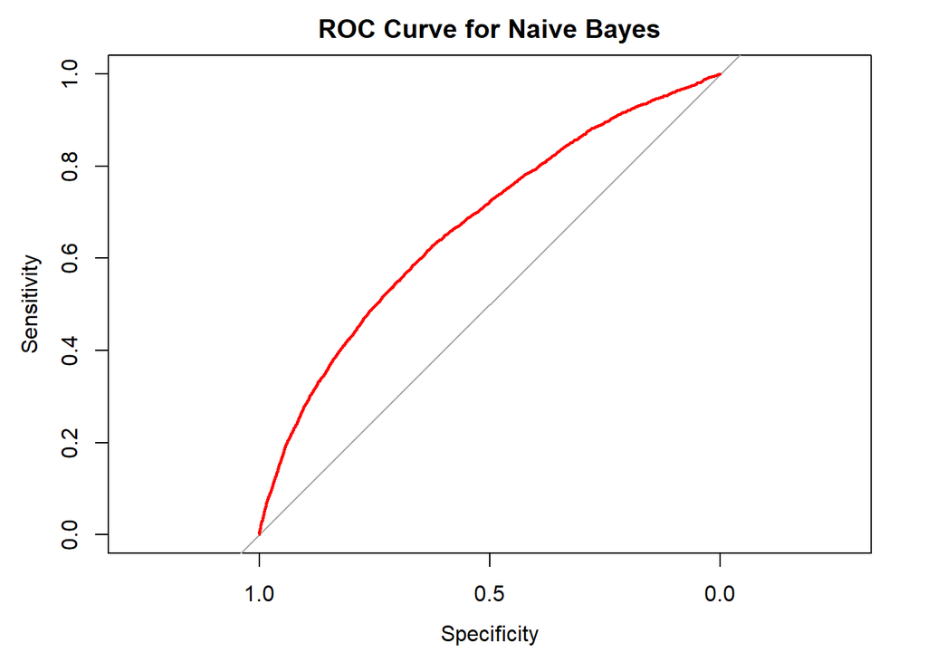

```r
plot(roc_obj, main = "ROC Curve for Naive Bayes", col = "red")
```

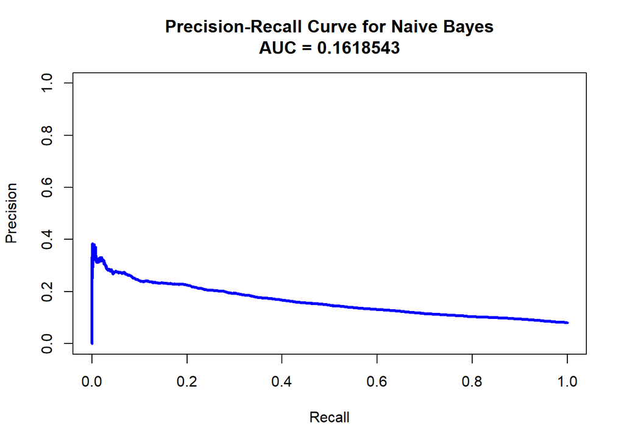

```r
# Calculate and plot Precision-Recall Curve
pr_curve <- pr.curve(scores.class0 = nb_probabilities, weights.class0 = as.numeric(test_y == "1"), curve = TRUE)
plot(pr_curve, main = "Precision-Recall Curve for Naive Bayes", col = "blue")
```

- F1-Score: 0.2366, 0.6706
- Precision-Recall Curve: Shows moderate balance but still struggles with minority class detection.
- Observations: The model is biased towards the majority class but performs better on overall metrics like F1-Score compared to the downsampled approach.

### Option 2: Use downsampling Methods to Balance Training Data

Balance dataset using downsampling

```r
# Perform downsampling
set.seed(123)  # Ensure reproducibility
train_data_balanced <- downSample(x = train_data %>% select(-target),
                                  y = train_data$target,
                                  yname = "target")

# Separate predictors and target again after downsampling
train_x_balanced <- train_data_balanced %>% select(-target)
train_y_balanced <- train_data_balanced$target

# Print summary of the balanced data
table(train_y_balanced)  # Check class distribution
```

```
## train_y_balanced
##     0     1
## 19860 19860
```

```r
# Train Naive Bayes model on downsampled data
nb_model_downsampled <- naiveBayes(x = train_x_balanced, y = as.factor(train_y_balanced))

# Predict probabilities and class labels
nb_probabilities_downsampled <- predict(nb_model_downsampled, test_x, type = "raw")[, 2]
nb_predictions_downsampled <- predict(nb_model_downsampled, test_x)

# Evaluate using confusion matrix
conf_matrix_downsampled <- confusionMatrix(nb_predictions_downsampled, as.factor(test_y), positive = "1")
print(conf_matrix_downsampled)
```

```
## Confusion Matrix and Statistics
##
##           Reference
## Prediction     0     1
##          0 32301  1637
##          1 24236  3328
##
##                Accuracy : 0.5793
##                  95% CI : (0.5754, 0.5832)
##     No Information Rate : 0.9193
##     P-Value [Acc > NIR] : 1
##
##                   Kappa : 0.0785
##
##  Mcnemar's Test P-Value : <2e-16
##
##             Sensitivity : 0.67029
##             Specificity : 0.57132
##          Pos Pred Value : 0.12074
##          Neg Pred Value : 0.95176
##              Prevalence : 0.08073
##          Detection Rate : 0.05411
##    Detection Prevalence : 0.44818
##       Balanced Accuracy : 0.62081
##
##        'Positive' Class : 1
##
```

```r
# Extract Precision, Recall, and calculate F1-Score for downsampled model
precision_down <- conf_matrix_downsampled$byClass["Pos Pred Value"]
recall_down <- conf_matrix_downsampled$byClass["Sensitivity"]
f1_score_down <- 2 * ((precision_down * recall_down) / (precision_down + recall_down))
print(paste("F1-Score (Downsampled):", f1_score_down))
```

```
## [1] "F1-Score (Downsampled): 0.204617418303668"
```

```r
# Calculate AUC and plot ROC Curve for downsampled model
roc_obj_downsampled <- roc(as.factor(test_y), nb_probabilities_downsampled, levels = c("0", "1"), positive = "1")
auc_value_downsampled <- auc(roc_obj_downsampled)
print(paste("AUC (Downsampled):", auc_value_downsampled))
```

```
## [1] "AUC (Downsampled): 0.671046755093996"
```

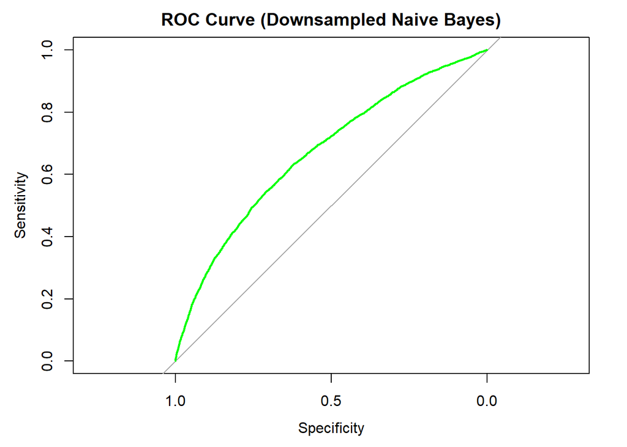

```r
plot(roc_obj_downsampled, main = "ROC Curve (Downsampled Naive Bayes)", col = "green")
```

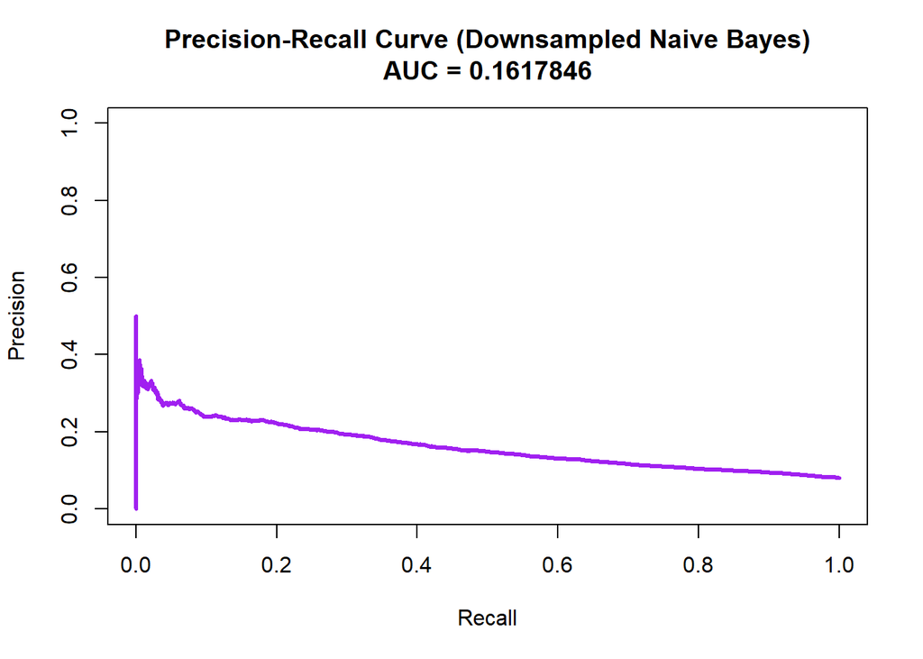

```r
# Calculate and plot Precision-Recall Curve for downsampled model
pr_curve_downsampled <- pr.curve(scores.class0 = nb_probabilities_downsampled, weights.class0 = as.numeric(test_y == "1"), curve = TRUE)
plot(pr_curve_downsampled, main = "Precision-Recall Curve (Downsampled Naive Bayes)", col = "purple")
```

- F1-Score: 0.2046, 0.6710
- Precision-Recall Curve: Indicates slightly improved recall but reduced precision.
- Observations: Downsampling improves sensitivity (recall) for the minority class but at the cost of precision, resulting in slightly worse F1-Score. Accuracy also drops due to the artificial balancing.

**Takeways:**

- Custom Priors: Better overall balance between precision and recall, maintaining higher accuracy and F1-Score.
- Downsampling: Helps capture more minority class instances (higher recall), but results in higher false positives, reducing precision and F1-Score.

### Option 3: Use oversampling method (Random OverSampling Examples) to balance Training Data

```r
colnames(train_x)
```

```
##  [1] "ext_source_2"
##  [2] "ext_source_3"
##  [3] "days_birth"
##  [4] "days_id_publish"
##  [5] "days_registration"
##  [6] "amt_credit"
##  [7] "days_last_phone_change"
##  [8] "days_employed"
##  [9] "amt_income_total"
## [10] "region_population_relative"
## [11] "hour_appr_process_start"
## [12] "cnt_children"
## [13] "organization_type_Business.Entity.Type.3"
## [14] "organization_type_Other"
## [15] "organization_type_Self.employed"
```

[output cut: 31 more lines]

```r
# Combine predictors and target into one dataset
train_data <- cbind(train_x, target = train_y)

# Apply ROSE directly to the dataset
set.seed(123)  # For reproducibility
train_data_oversampled <- ROSE(target ~ ., data = train_data, seed = 123)$data

# Separate predictors and target again after oversampling
train_x_oversampled <- train_data_oversampled %>% select(-target)
train_y_oversampled <- train_data_oversampled$target

# Check class distribution to ensure oversampling worked
table(train_y_oversampled)
```

```
## train_y_oversampled
##      0      1
## 123059 122950
```

```r
# Train Naive Bayes model on oversampled data
nb_model_oversampled <- naiveBayes(x = train_x_oversampled, y = as.factor(train_y_oversampled))

# Predict probabilities and class labels
nb_probabilities_oversampled <- predict(nb_model_oversampled, test_x, type = "raw")[, 2]
nb_predictions_oversampled <- predict(nb_model_oversampled, test_x)

# Evaluate using confusion matrix
conf_matrix_oversampled <- confusionMatrix(nb_predictions_oversampled, as.factor(test_y), positive = "1")
print(conf_matrix_oversampled)
```

```
## Confusion Matrix and Statistics
##
##           Reference
## Prediction     0     1
##          0 31530  1585
##          1 25007  3380
##
##                Accuracy : 0.5676
##                  95% CI : (0.5637, 0.5715)
##     No Information Rate : 0.9193
##     P-Value [Acc > NIR] : 1
##
##                   Kappa : 0.0757
##
##  Mcnemar's Test P-Value : <2e-16
##
##             Sensitivity : 0.68077
##             Specificity : 0.55769
##          Pos Pred Value : 0.11907
##          Neg Pred Value : 0.95214
##              Prevalence : 0.08073
##          Detection Rate : 0.05496
##    Detection Prevalence : 0.46156
##       Balanced Accuracy : 0.61923
##
##        'Positive' Class : 1
##
```

```r
# Calculate Precision, Recall, and F1-Score
precision_oversampled <- conf_matrix_oversampled$byClass["Pos Pred Value"]
recall_oversampled <- conf_matrix_oversampled$byClass["Sensitivity"]
f1_score_oversampled <- 2 * ((precision_oversampled * recall_oversampled) / (precision_oversampled + recall_oversampled))
print(paste("F1-Score (Oversampled):", f1_score_oversampled))
```

```
## [1] "F1-Score (Oversampled): 0.202686495562485"
```

```r
# Calculate AUC and plot ROC Curve
roc_obj_oversampled <- roc(as.factor(test_y), nb_probabilities_oversampled, levels = c("0", "1"), positive = "1")
auc_value_oversampled <- auc(roc_obj_oversampled)
print(paste("AUC (Oversampled):", auc_value_oversampled))
```

```
## [1] "AUC (Oversampled): 0.670586740325174"
```

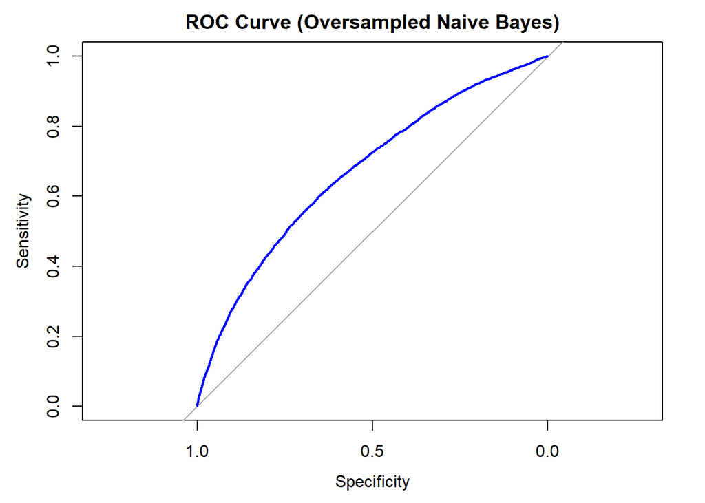

```r
plot(roc_obj_oversampled, main = "ROC Curve (Oversampled Naive Bayes)", col = "blue")
```

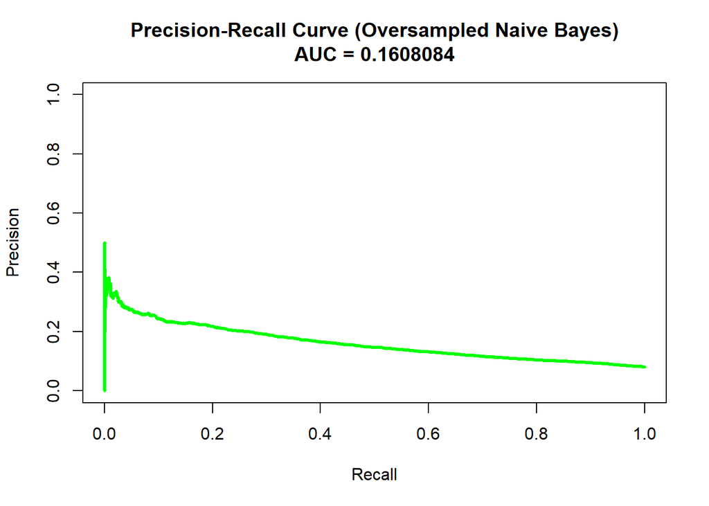

```r
# Calculate and plot Precision-Recall Curve
pr_curve_oversampled <- pr.curve(scores.class0 = nb_probabilities_oversampled, weights.class0 = as.numeric(test_y == "1"), curve = TRUE)
plot(pr_curve_oversampled, main = "Precision-Recall Curve (Oversampled Naive Bayes)", col = "green")
```

### Option 4: Use oversampling and downsampling Methods to Balance Training Data

```r
# Combine predictors and target into one dataset
train_data <- cbind(train_x, target = train_y)

# Apply both SMOTE (oversampling) and downsampling using ROSE
set.seed(123)  # For reproducibility
train_data_combined <- ROSE(target ~ ., data = train_data, p = 0.5, seed = 123)$data

# Separate predictors and target again after combining oversampling and downsampling
train_x_combined <- train_data_combined %>% select(-target)
train_y_combined <- train_data_combined$target

# Check class distribution to ensure combination worked
table(train_y_combined)
```

```
## train_y_combined
##      0      1
## 123059 122950
```

```r
# Train Naive Bayes model on combined dataset
nb_model_combined <- naiveBayes(x = train_x_combined, y = as.factor(train_y_combined))

# Predict probabilities and class labels
nb_probabilities_combined <- predict(nb_model_combined, test_x, type = "raw")[, 2]
nb_predictions_combined <- predict(nb_model_combined, test_x)

# Evaluate using confusion matrix
conf_matrix_combined <- confusionMatrix(nb_predictions_combined, as.factor(test_y), positive = "1")
print(conf_matrix_combined)
```

```
## Confusion Matrix and Statistics
##
##           Reference
## Prediction     0     1
##          0 31530  1585
##          1 25007  3380
##
##                Accuracy : 0.5676
##                  95% CI : (0.5637, 0.5715)
##     No Information Rate : 0.9193
##     P-Value [Acc > NIR] : 1
##
##                   Kappa : 0.0757
##
##  Mcnemar's Test P-Value : <2e-16
##
##             Sensitivity : 0.68077
##             Specificity : 0.55769
##          Pos Pred Value : 0.11907
##          Neg Pred Value : 0.95214
##              Prevalence : 0.08073
##          Detection Rate : 0.05496
##    Detection Prevalence : 0.46156
##       Balanced Accuracy : 0.61923
##
##        'Positive' Class : 1
##
```

```r
# Extract Precision, Recall, and calculate F1-Score
precision_combined <- conf_matrix_combined$byClass["Pos Pred Value"]
recall_combined <- conf_matrix_combined$byClass["Sensitivity"]
f1_score_combined <- 2 * ((precision_combined * recall_combined) / (precision_combined + recall_combined))
print(paste("F1-Score (Combined):", f1_score_combined))
```

```
## [1] "F1-Score (Combined): 0.202686495562485"
```

```r
# Calculate AUC and plot ROC Curve
roc_obj_combined <- roc(as.factor(test_y), nb_probabilities_combined, levels = c("0", "1"), positive = "1")
auc_value_combined <- auc(roc_obj_combined)
print(paste("AUC (Combined):", auc_value_combined))
```

```
## [1] "AUC (Combined): 0.670586740325174"
```

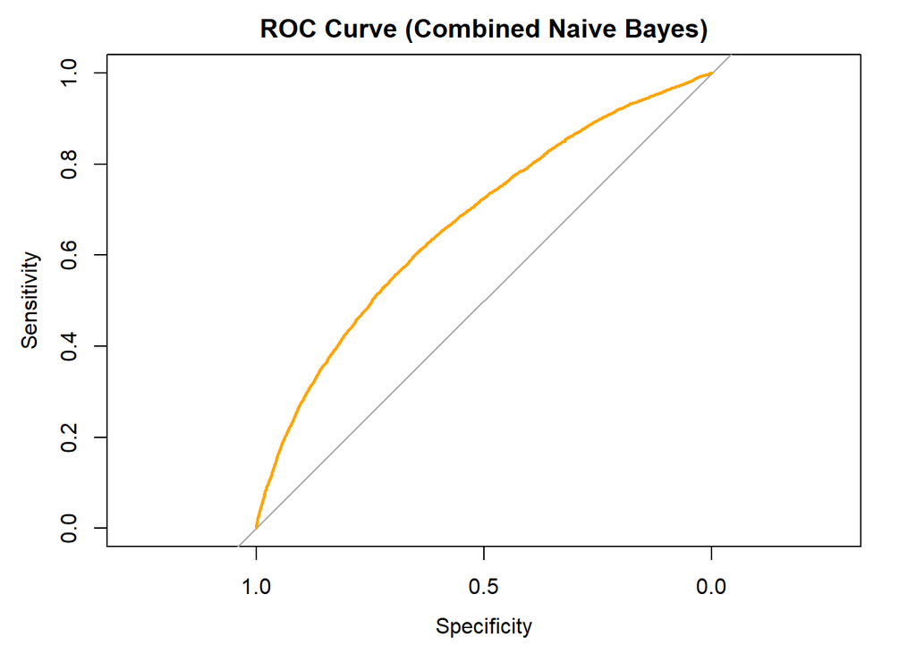

```r
plot(roc_obj_combined, main = "ROC Curve (Combined Naive Bayes)", col = "orange")
```

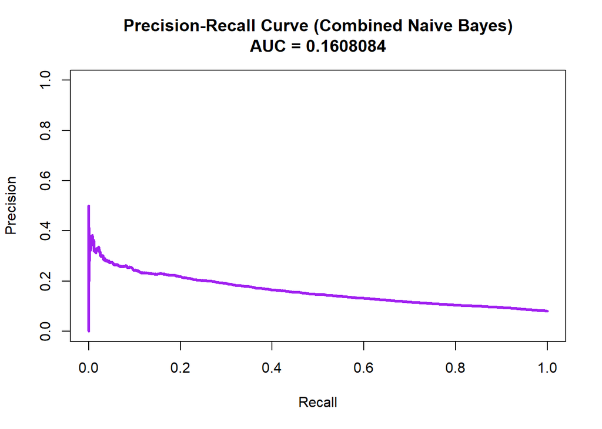

```r
# Calculate and plot Precision-Recall Curve
pr_curve_combined <- pr.curve(scores.class0 = nb_probabilities_combined, weights.class0 = as.numeric(test_y == "1"), curve = TRUE)
plot(pr_curve_combined, main = "Precision-Recall Curve (Combined Naive Bayes)", col = "purple")
```

### Comparison table

```r
# Create a data frame for comparison
comparison_table <- data.frame(
  Model = c("NB Custom Priors", "NB Downsampling", "NB Oversampling", "NB Combined Sampling"),
  F1_Score = c(f1_score_nb, f1_score_down, f1_score_oversampled, f1_score_combined),
  AUC = c(auc_value, auc_value_downsampled, auc_value_oversampled, auc_value_combined),
  Sensitivity = c(recall, recall_down, recall_oversampled, recall_combined),
  Precision = c(precision, precision_down, precision_oversampled, precision_combined),
  Accuracy = c(conf_matrix$overall["Accuracy"],
               conf_matrix_downsampled$overall["Accuracy"],
               conf_matrix_oversampled$overall["Accuracy"],
               conf_matrix_combined$overall["Accuracy"])
)

# Display the table using kable
kable(comparison_table, caption = "Comparison of Naive Bayes Models with Various Sampling Methods")
```

Comparison of Naive Bayes Models with Various Sampling Methods

| Model | F1_Score | AUC | Sensitivity | Precision | Accuracy |
| --- | --- | --- | --- | --- | --- |
| NB Custom Priors | 0.2366369 | 0.6706540 | 0.3820745 | 0.1713950 | 0.8009983 |
| NB Downsampling | 0.2046174 | 0.6710468 | 0.6702920 | 0.1207372 | 0.5793145 |
| NB Oversampling | 0.2026865 | 0.6705867 | 0.6807654 | 0.1190686 | 0.5676238 |
| NB Combined Sampling | 0.2026865 | 0.6705867 | 0.6807654 | 0.1190686 | 0.5676238 |

- Custom Priors is the preferred method for maintaining a balance between performance and accuracy, especially for business cases where overall accuracy is critical.
- Use Downsampling or Oversampling if identifying minority class instances (sensitivity) is more important than overall accuracy.
- Combined Sampling offers no added value over oversampling; therefore, it may not be the optimal choice.

## Random Forest

```r
# Train a Random Forest with class weights
set.seed(123)
rf_model <- randomForest(
  x = train_x,
  y = train_y,
  classwt = c(1, sum(train_y == 0) / sum(train_y == 1)),  # Class weights
  trControl = trainControl(method = "cv", number = 3),
  ntree = 50, # Reduce the number of trees for memory constraints
  importance = TRUE
)

# Predictions
rf_predictions <- predict(rf_model, test_x)
rf_probabilities <- predict(rf_model, test_x, type = "prob")

# Evaluate performance
rf_confusion <- confusionMatrix(rf_predictions, test_y, positive = "1")  # Save output to a variable'
print(rf_confusion)
```

```
## Confusion Matrix and Statistics
##
##           Reference
## Prediction     0     1
##          0 56524  4956
##          1    13     9
##
##                Accuracy : 0.9192
##                  95% CI : (0.917, 0.9213)
##     No Information Rate : 0.9193
##     P-Value [Acc > NIR] : 0.5274
##
##                   Kappa : 0.0029
##
##  Mcnemar's Test P-Value : <2e-16
##
##             Sensitivity : 0.0018127
##             Specificity : 0.9997701
##          Pos Pred Value : 0.4090909
##          Neg Pred Value : 0.9193884
##              Prevalence : 0.0807291
##          Detection Rate : 0.0001463
##    Detection Prevalence : 0.0003577
##       Balanced Accuracy : 0.5007914
##
##        'Positive' Class : 1
##
```

```r
# Calculate metrics
roc_obj <- roc(as.factor(test_y), rf_probabilities[, 2], levels = c("0", "1"), positive = "1")
auc_value <- auc(roc_obj)
```

```r
pr_curve <- pr.curve(scores.class0 = rf_probabilities[, 2], weights.class0 = as.numeric(test_y == "1"), curve = TRUE)

# Extract precision, recall, F1-Score
rf_precision <- rf_confusion$byClass["Pos Pred Value"]
rf_recall <- rf_confusion$byClass["Sensitivity"]
rf_f1_score <- 2 * ((rf_precision * rf_recall) / (rf_precision + rf_recall))

# Print results
print(paste("AUC:", auc_value))
```

```
## [1] "AUC: 0.672425543639123"
```

```r
print(paste("F1-Score:", rf_f1_score))
```

```
## [1] "F1-Score: 0.00360938439943854"
```

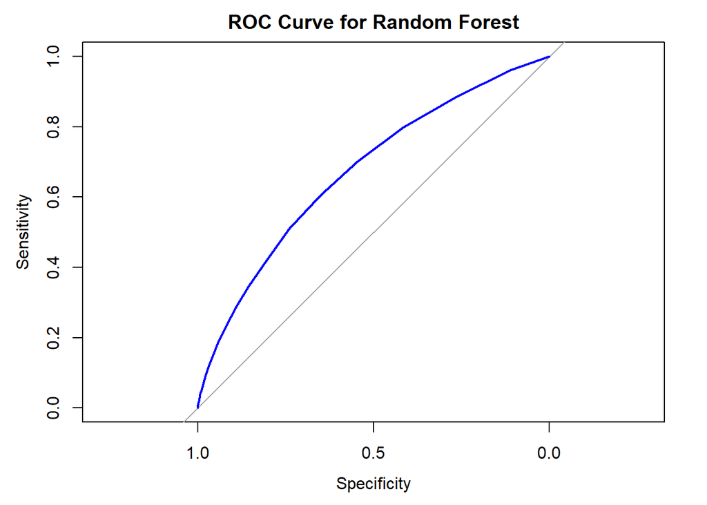

```r
plot(roc_obj, main = "ROC Curve for Random Forest", col = "blue")
```

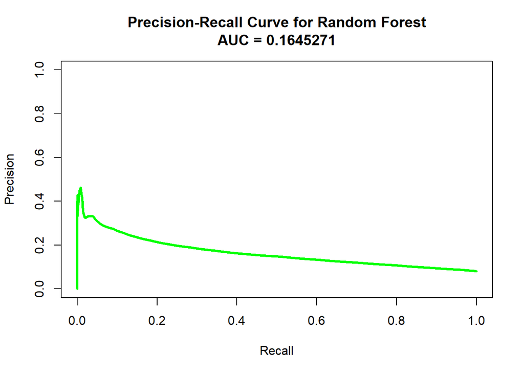

```r
plot(pr_curve, main = "Precision-Recall Curve for Random Forest", col = "green")
```

## XGBoost

```r
# Prepare data for XGBoost
train_matrix <- xgb.DMatrix(data = as.matrix(train_x), label = as.numeric(train_y) - 1)
test_matrix <- xgb.DMatrix(data = as.matrix(test_x), label = as.numeric(test_y) - 1)

# Set parameters with class weights
params <- list(
  objective = "binary:logistic",
  eval_metric = "auc",
  scale_pos_weight = sum(train_y == 0) / sum(train_y == 1)  # Class weights
)

# Train the model
set.seed(123)
xgb_model <- xgb.train(
  params = params,
  data = train_matrix,
  nrounds = 100,
  watchlist = list(val = test_matrix, train = train_matrix),
  early_stopping_rounds = 10
)
```

```
## Multiple eval metrics are present. Will use train_auc for early stopping.
## Will train until train_auc hasn't improved in 10 rounds.
##
```

```r
# Predictions
xgb_predictions <- predict(xgb_model, test_matrix)
xgb_class <- ifelse(xgb_predictions > 0.5, 1, 0)

# Evaluate performance
confusionMatrix(factor(xgb_class), test_y, positive = "1")
```

```
## Confusion Matrix and Statistics
##
##           Reference
## Prediction     0     1
##          0 40861  1991
##          1 15676  2974
##
##                Accuracy : 0.7127
##                  95% CI : (0.7091, 0.7163)
##     No Information Rate : 0.9193
##     P-Value [Acc > NIR] : 1
##
##                   Kappa : 0.1425
##
##  Mcnemar's Test P-Value : <2e-16
##
##             Sensitivity : 0.59899
##             Specificity : 0.72273
##          Pos Pred Value : 0.15946
##          Neg Pred Value : 0.95354
##              Prevalence : 0.08073
##          Detection Rate : 0.04836
##    Detection Prevalence : 0.30324
##       Balanced Accuracy : 0.66086
##
##        'Positive' Class : 1
##
```

```r
# Calculate AUC for XGBoost
xgb_roc_obj <- roc(as.factor(test_y), xgb_predictions, levels = c("0", "1"), positive = "1")
xgb_auc_value <- auc(xgb_roc_obj)

# Calculate precision, recall, and F1-Score for XGBoost
xgb_confusion <- confusionMatrix(factor(xgb_class), test_y, positive = "1")
xgb_precision <- xgb_confusion$byClass["Pos Pred Value"]
xgb_recall <- xgb_confusion$byClass["Sensitivity"]
xgb_f1_score <- 2 * ((xgb_precision * xgb_recall) / (xgb_precision + xgb_recall))

# Print results
print(paste("AUC for XGBoost:", xgb_auc_value))
```

```
## [1] "AUC for XGBoost: 0.721822950084057"
```

```r
print(paste("F1-Score for XGBoost:", xgb_f1_score))
```

```
## [1] "F1-Score for XGBoost: 0.251873809019691"
```

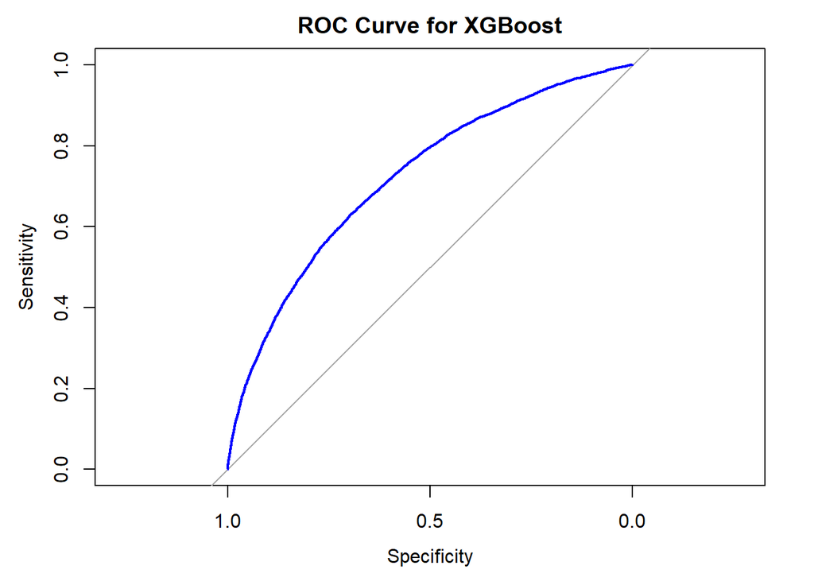

```r
plot(xgb_roc_obj, main = "ROC Curve for XGBoost", col = "blue")
```